# R Bootcamp Einstein 2017

Michoel Snow

August 8-9, 2017

# SECTION 1 - The Basics

# Installing R

If you don’t have them already installed you need to download and install R and R studio

- Download R
  - https://cran.r-project.org/
- R Studio
  - https://www.rstudio.com/products/rstudio/download/

# Introduction to R

- R is an open source programming environment
- It is most commonly used for statistical computing and graphics
- The basic functionality of R can be extended with ‘packages’

# Resources for R

- R for data science http://r4ds.had.co.nz
  - Served as inspiration for a lot of this bootcamp
  - Written by programmers at R Studio
- R Programming for Data Science https://bookdown.org/rdpeng/rprogdatascience/
- R Bootcamp https://www.jaredknowles.com/r-bootcamp/

# Introduction to R studio

- R studio is an IDE within which you can write/edit code, run code, display plots/graphics and a whole host of other functions

# Getting Started

- Go to https://github.com/mseinstein/ to download the Presentions > RBootCamp > r_bootcamp_einstein_2017.R file
- All the code presented here is within that R file

# Running code in R

- To run any line of code use `CTRL`+`Enter` or `Cmd`+`Enter`
  - R will run the highlighted code OR
  - R will run the line of code which the cursor is on

# Installing and Loading packages

- The power of R can be extended with packages
- Tidyverse is a collection of R packages that share common philosophies and are designed to work together
  - This is the main package we will be using
- You install a package with the `install.packages("Pkg Name")`, e.g., `install.packages("tidyverse")`
  - Only needs to be done once per machine
- To load a package call the `library` function, e.g., `library(tidyverse)`
  - Needs to be loaded every session you want to use it (usually everytime you open R studio)

# Key Symbols

- < -
  - Assignment operator, e.g. x <- 5
  - The equals sign, =, will work as a substitution in most but not all cases
- `#`
  - Denotes a comment
  - All text following the `#` will be ignored
- `?`function_name
  - Opens the Documentation for the function
- `??`term
  - Searches the help documentation for the queried string

# Structure of This Presentation

1. Visualization of Data
2. Manipulation of Data
3. Importing/cleaning of Data

# SECTION 2 - Data Visualisations

# ggplot2

- ggplot2 is a plotting system for R, based on the grammar of graphics
- See http://vita.had.co.nz/papers/layered-grammar.pdf for an in-depth discussion

`library(tidyverse)`

# Graphics in ggplot are built in layers

# mpg dataset

```r
# mpg is a ggplot dataset of fuel economy data from 1999 and 2008 for 38 popular models of car
mpg
```

```
## # A tibble: 234 × 11
##    manufacturer      model displ  year   cyl      trans   drv   cty   hwy    fl   class
##           <chr>      <chr> <dbl> <int> <int>      <chr> <chr> <int> <int> <chr>   <chr>
## 1          audi         a4   1.8  1999     4   auto(l5)     f    18    29     p compact
## 2          audi         a4   1.8  1999     4 manual(m5)     f    21    29     p compact
## 3          audi         a4   2.0  2008     4 manual(m6)     f    20    31     p compact
## 4          audi         a4   2.0  2008     4   auto(av)     f    21    30     p compact
## 5          audi         a4   2.8  1999     6   auto(l5)     f    16    26     p compact
## 6          audi         a4   2.8  1999     6 manual(m5)     f    18    26     p compact
## 7          audi         a4   3.1  2008     6   auto(av)     f    18    27     p compact
## 8          audi a4 quattro   1.8  1999     4 manual(m5)     4    18    26     p compact
## 9          audi a4 quattro   1.8  1999     4   auto(l5)     4    16    25     p compact
## 10         audi a4 quattro   2.0  2008     4 manual(m6)     4    20    28     p compact
## # ... with 224 more rows
```

```r
summary(mpg)
```

```
##  manufacturer          model               displ            year           cyl           trans
##  Length:234         Length:234         Min.   :1.600   Min.   :1999   Min.   :4.000   Length:234
##  Class :character   Class :character   1st Qu.:2.400   1st Qu.:1999   1st Qu.:4.000   Class :character
##  Mode  :character   Mode  :character   Median :3.300   Median :2004   Median :6.000   Mode  :character
##                                        Mean   :3.472   Mean   :2004   Mean   :5.889
##                                        3rd Qu.:4.600   3rd Qu.:2008   3rd Qu.:8.000
##                                        Max.   :7.000   Max.   :2008   Max.   :8.000
##      drv                 cty             hwy             fl               class
##  Length:234         Min.   : 9.00   Min.   :12.00   Length:234         Length:234
##  Class :character   1st Qu.:14.00   1st Qu.:18.00   Class :character   Class :character
##  Mode  :character   Median :17.00   Median :24.00   Mode  :character   Mode  :character
##                     Mean   :16.86   Mean   :23.44
##                     3rd Qu.:19.00   3rd Qu.:27.00
##                     Max.   :35.00   Max.   :44.00
```

```r
mpg$drv
```

```
##   [1] "f" "f" "f" "f" "f" "f" "f" "4" "4" "4" "4" "4" "4" "4" "4" "4" "4" "4" "r" "r" "r" "r" "r" "r" "r" "r" "r" "r"
##  [29] "4" "4" "4" "4" "f" "f" "f" "f" "f" "f" "f" "f" "f" "f" "f" "f" "f" "f" "f" "f" "4" "4" "4" "4" "4" "4" "4" "4"
##  [57] "4" "4" "4" "4" "4" "4" "4" "4" "4" "4" "4" "4" "4" "4" "4" "4" "4" "4" "r" "r" "r" "4" "4" "4" "4" "4" "4" "4"
##  [85] "4" "4" "4" "4" "4" "4" "r" "r" "r" "r" "r" "r" "r" "r" "r" "f" "f" "f" "f" "f" "f" "f" "f" "f" "f" "f" "f" "f"
## [113] "f" "f" "f" "f" "f" "f" "f" "f" "f" "f" "4" "4" "4" "4" "4" "4" "4" "4" "4" "4" "4" "4" "r" "r" "r" "4" "4" "4"
## [141] "4" "f" "f" "f" "f" "f" "f" "f" "f" "f" "4" "4" "4" "4" "f" "f" "f" "f" "f" "4" "4" "4" "4" "4" "4" "4" "4" "4"
## [169] "4" "4" "4" "4" "4" "4" "4" "4" "4" "4" "4" "f" "f" "f" "f" "f" "f" "f" "f" "f" "f" "f" "f" "f" "f" "f" "f" "f"
## [197] "f" "f" "4" "4" "4" "4" "4" "4" "4" "4" "4" "f" "f" "f" "f" "f" "f" "f" "f" "f" "f" "f" "f" "f" "f" "f" "f" "f"
## [225] "f" "f" "f" "f" "f" "f" "f" "f" "f" "f"
```

# ggplot command

The ggplot command begins a plot to which you can add layers

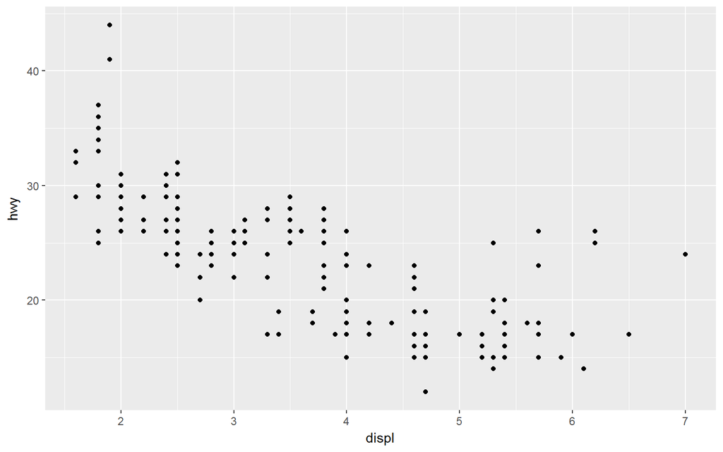

```r
ggplot(data = mpg) + geom_point(mapping = aes(x = displ, y = hwy))
```

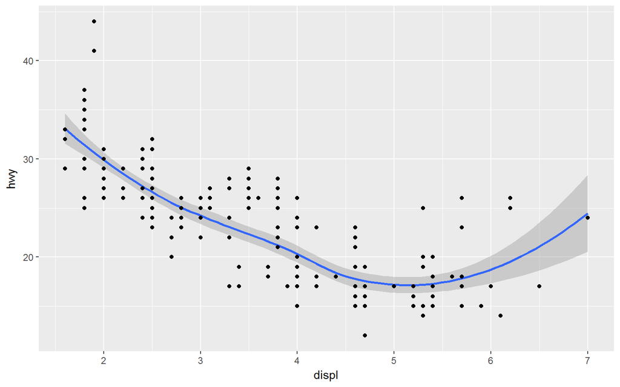

```r
ggplot(data = mpg) + geom_smooth(mapping = aes(x = displ, y = hwy)) + geom_point(mapping = aes(x = displ, y = hwy))
```

# Variable propagation

By inserting x and y into ggplot, all layers will use those parameters unless otherwise specified

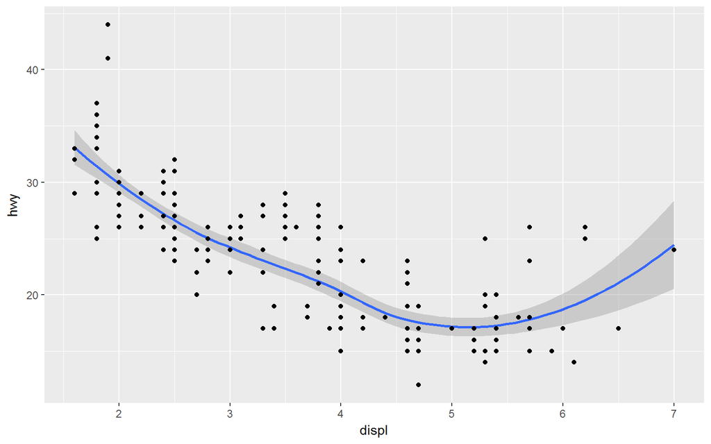

```r
ggplot(data = mpg, mapping = aes(x = displ, y = hwy)) +
  geom_smooth() +
  geom_point()
```

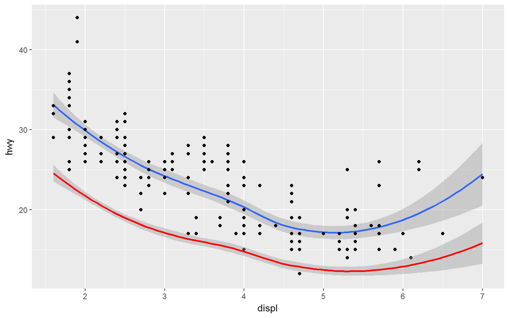

```r
ggplot(data = mpg, mapping = aes(x = displ, y = hwy)) +
  geom_smooth() +
  geom_point() +
  geom_smooth(mapping = aes(x = displ,y = cty),color = "red")
```

# Features vs Variables

Note: if you want to plot a variable to a feature like color or size, it must go in the aes() term, if you just want to set them at a certain value they go outside the aes

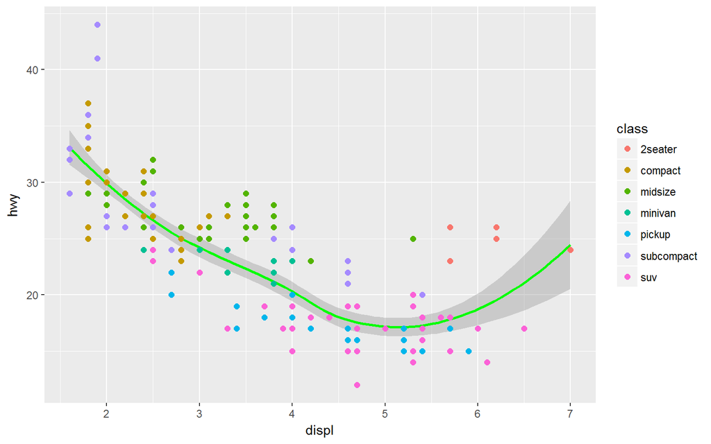

```r
ggplot(mpg, aes(displ,hwy)) +
  geom_smooth(color = "green") +
  geom_point(aes(color=class),size=2)
```

# Facets

You can also split the plot into subplots based on a varible using `facet`

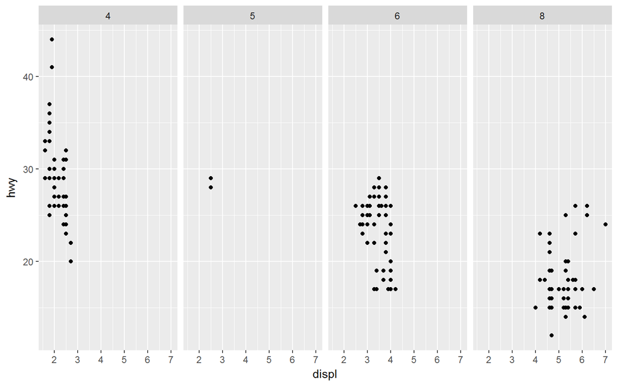

```r
ggplot(mpg, aes(displ, hwy)) + geom_point() + facet_grid(. ~ cyl)
```

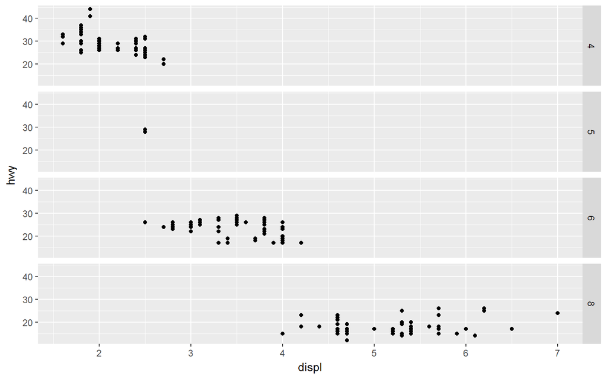

```r
ggplot(mpg, aes(displ, hwy)) + geom_point() + facet_grid(cyl ~ .)
```

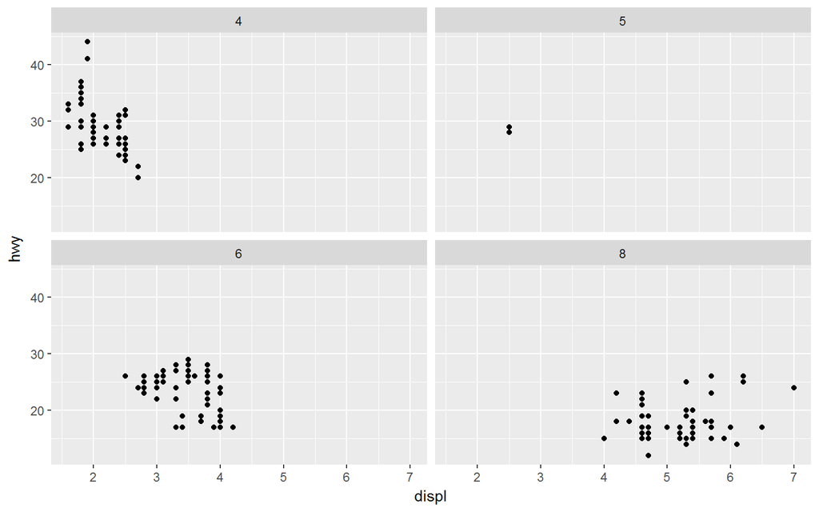

```r
ggplot(mpg, aes(displ, hwy)) + geom_point() + facet_wrap(~cyl)
```

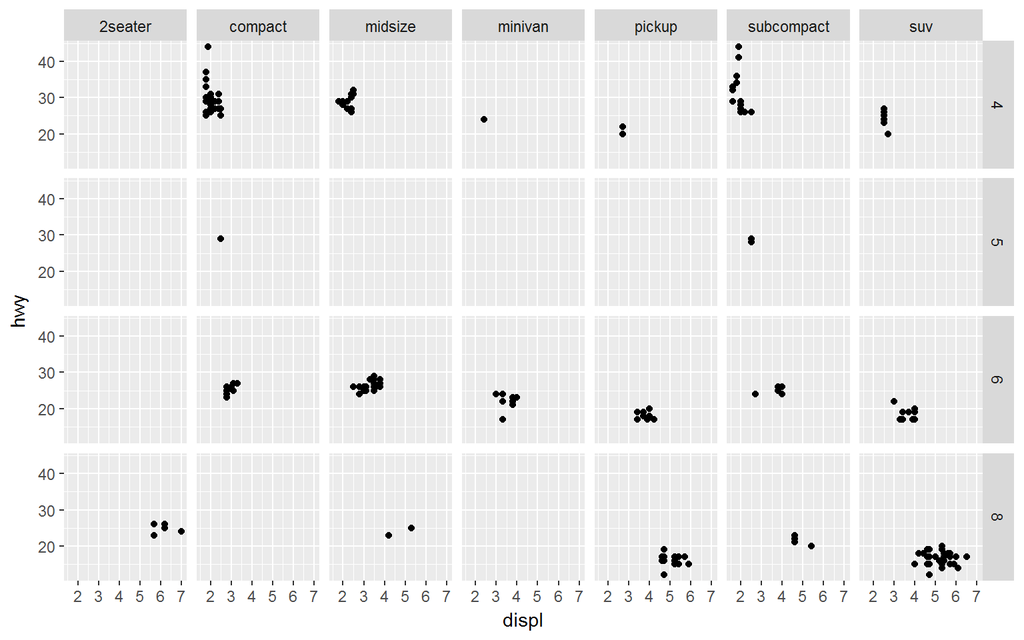

```r
ggplot(mpg, aes(displ, hwy)) + geom_point() + facet_grid(cyl ~ class)
```

# Exercises

Try to make some of the following plots:

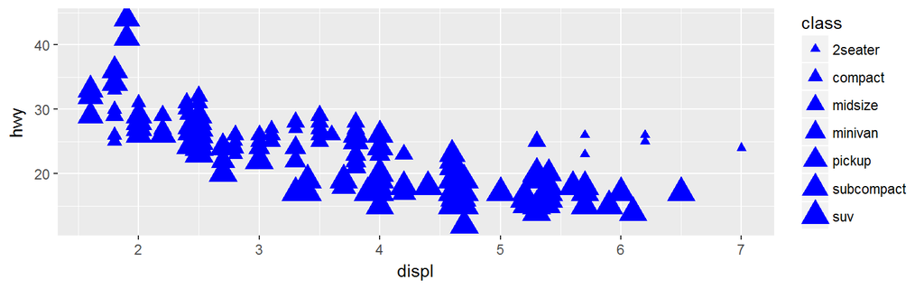

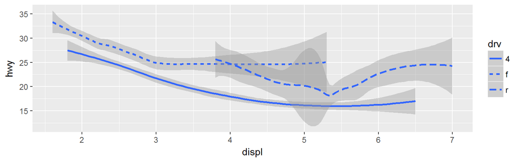

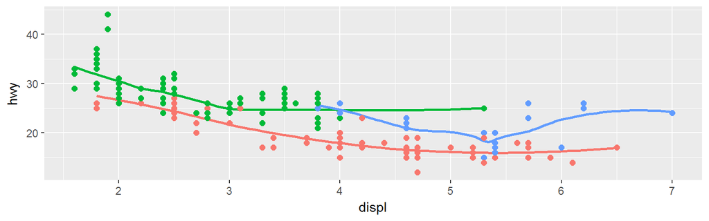

# Graphics and Statistical Transformations

This time we will be using the `diamonds` dataset

```r
summary(diamonds)
```

```
##      carat               cut        color        clarity          depth           table           price
##  Min.   :0.2000   Fair     : 1610   D: 6775   SI1    :13065   Min.   :43.00   Min.   :43.00   Min.   :  326
##  1st Qu.:0.4000   Good     : 4906   E: 9797   VS2    :12258   1st Qu.:61.00   1st Qu.:56.00   1st Qu.:  950
##  Median :0.7000   Very Good:12082   F: 9542   SI2    : 9194   Median :61.80   Median :57.00   Median : 2401
##  Mean   :0.7979   Premium  :13791   G:11292   VS1    : 8171   Mean   :61.75   Mean   :57.46   Mean   : 3933
##  3rd Qu.:1.0400   Ideal    :21551   H: 8304   VVS2   : 5066   3rd Qu.:62.50   3rd Qu.:59.00   3rd Qu.: 5324
##  Max.   :5.0100                     I: 5422   VVS1   : 3655   Max.   :79.00   Max.   :95.00   Max.   :18823
##                                     J: 2808   (Other): 2531
##        x                y                z
##  Min.   : 0.000   Min.   : 0.000   Min.   : 0.000
##  1st Qu.: 4.710   1st Qu.: 4.720   1st Qu.: 2.910
##  Median : 5.700   Median : 5.710   Median : 3.530
##  Mean   : 5.731   Mean   : 5.735   Mean   : 3.539
##  3rd Qu.: 6.540   3rd Qu.: 6.540   3rd Qu.: 4.040
##  Max.   :10.740   Max.   :58.900   Max.   :31.800
##
```

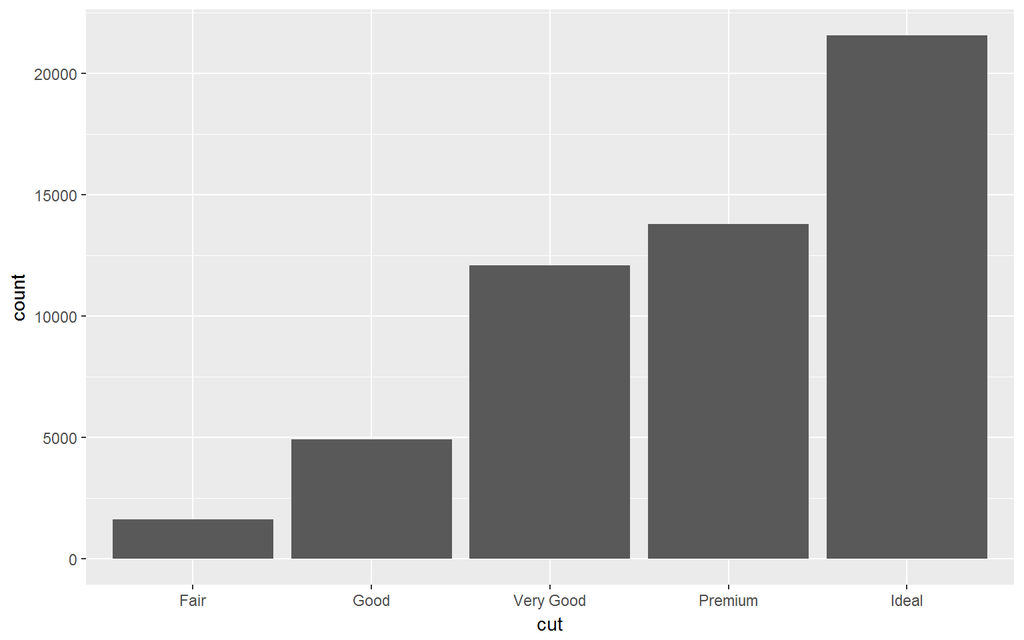

```r
ggplot(diamonds, aes(cut)) + geom_bar()
```

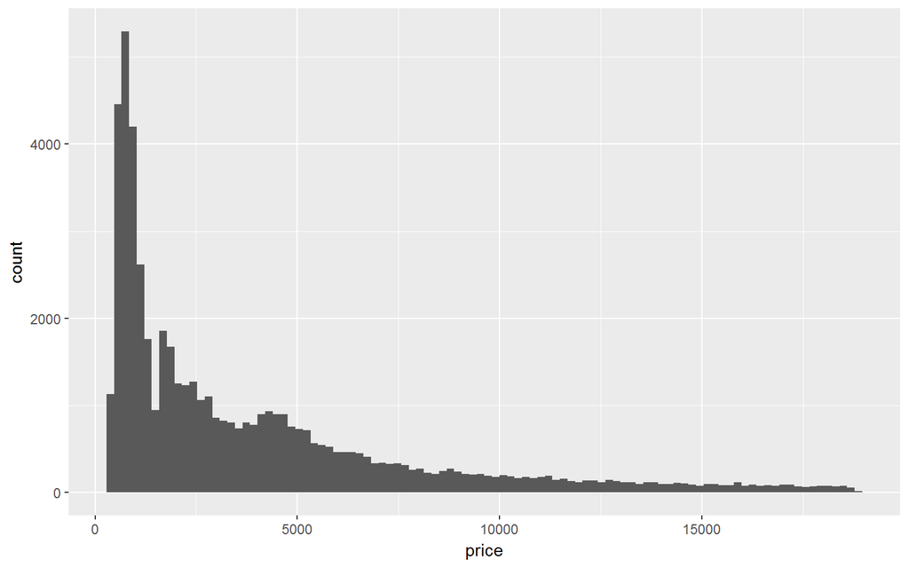

```r
ggplot(diamonds, aes(price)) + geom_histogram(bins = 100)
```

# Computed Variables

- Bar charts, histograms and the other plots in the one variable section of the ggplot2 cheat sheet bin your data based on a single variable
- You can determine the computed variables of a graphic by using the help function:
  - Computed variables
    - count
      - Number of points in bin
    - prop
      - Groupwise proportion

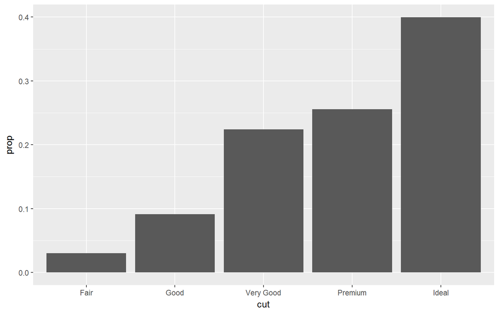

```r
ggplot(diamonds) + geom_bar(aes(x = cut, y = ..prop.., group = 1))
```

# Position adjustments

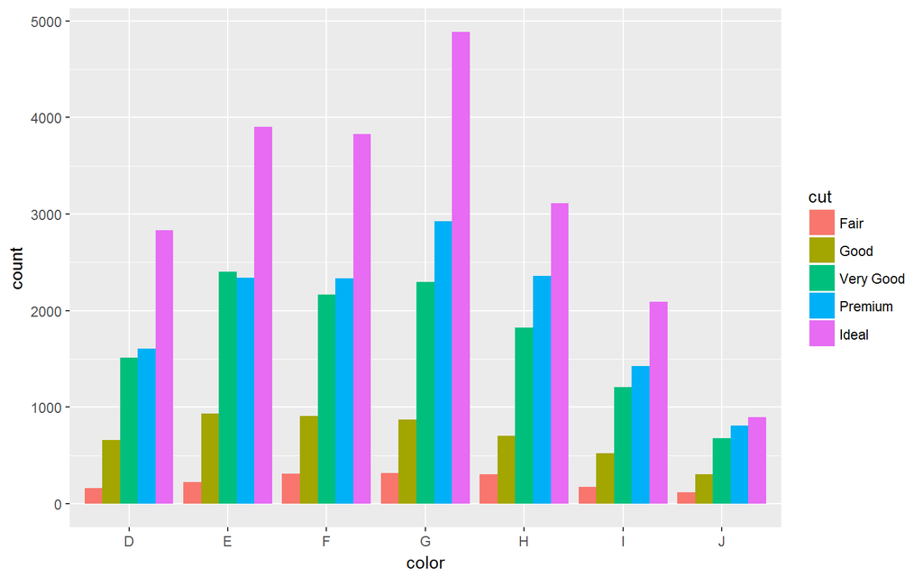

```r
ggplot(diamonds) + geom_bar(aes(x = color, fill = cut), position = "dodge")
```

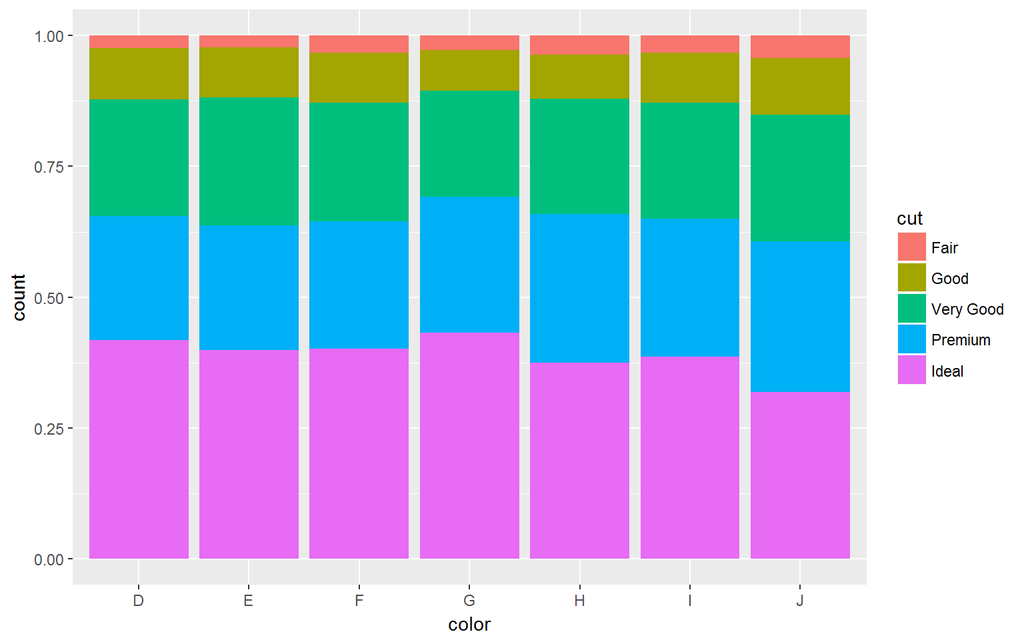

```r
ggplot(diamonds) + geom_bar(aes(x = color, fill = cut), position = "fill")
```

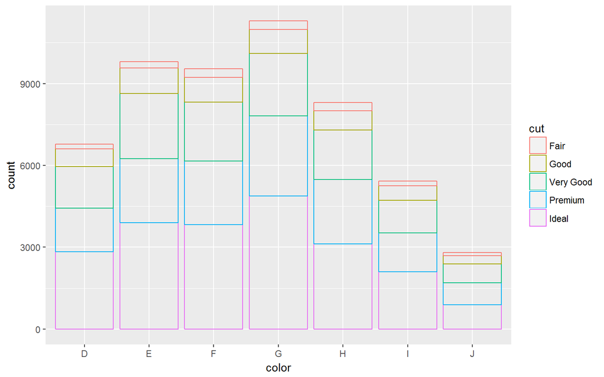

```r
ggplot(diamonds) + geom_bar(aes(x = color, color = cut), position = "stack", fill = NA)
```

# Example Plots

plots from http://r-statistics.co/Top50-Ggplot2-Visualizations-MasterList-R-Code.html

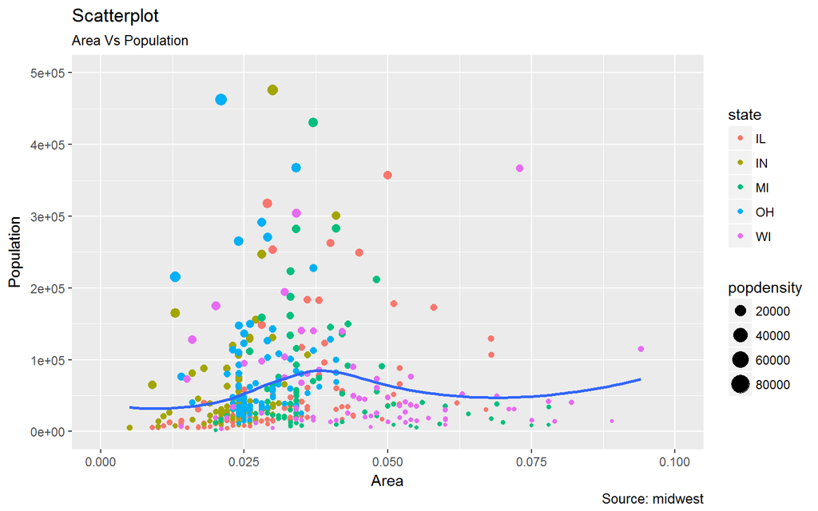

```r
ggplot(midwest, aes(x=area, y=poptotal)) +
  geom_point(aes(col=state, size=popdensity)) +
  geom_smooth(method="loess", se=F) + xlim(c(0, 0.1)) + ylim(c(0, 500000)) +
  labs(subtitle="Area Vs Population", y="Population", x="Area", title="Scatterplot", caption = "Source: midwest")
```

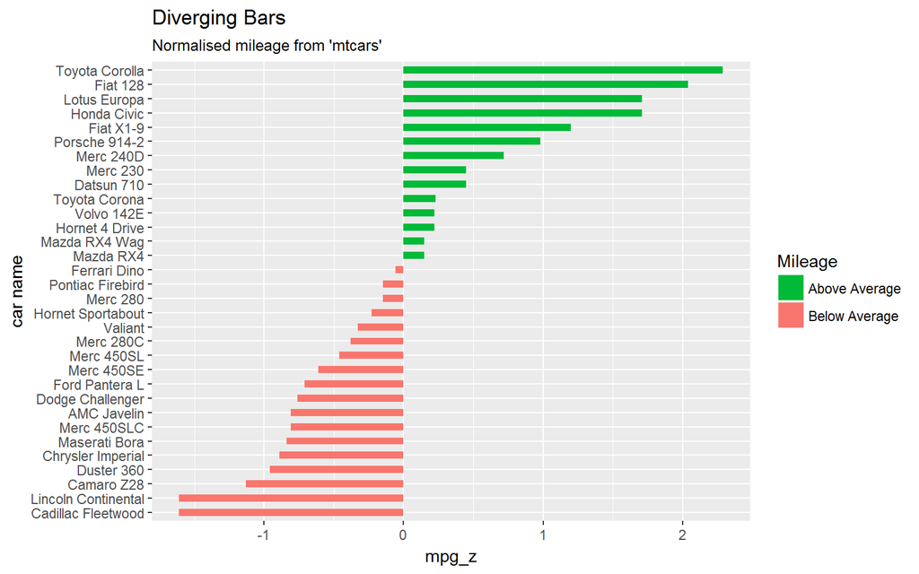

```r
mtcars$`car name` <- rownames(mtcars)  # create new column for car names
mtcars$mpg_z <- round((mtcars$mpg - mean(mtcars$mpg))/sd(mtcars$mpg), 2)  # compute normalized mpg
mtcars$mpg_type <- ifelse(mtcars$mpg_z < 0, "below", "above")  # above / below avg flag
mtcars <- mtcars[order(mtcars$mpg_z), ]  # sort
mtcars$`car name` <- factor(mtcars$`car name`, levels = mtcars$`car name`)  # convert to factor to retain sorted order in plot.

ggplot(mtcars, aes(x=`car name`, y=mpg_z, label=mpg_z)) +
  geom_bar(stat='identity', aes(fill=mpg_type), width=.5)  +
  scale_fill_manual(name="Mileage",
                    labels = c("Above Average", "Below Average"),
                    values = c("above"="#00ba38", "below"="#f8766d")) +
  labs(subtitle="Normalised mileage from 'mtcars'", title= "Diverging Bars") +
  coord_flip()
```

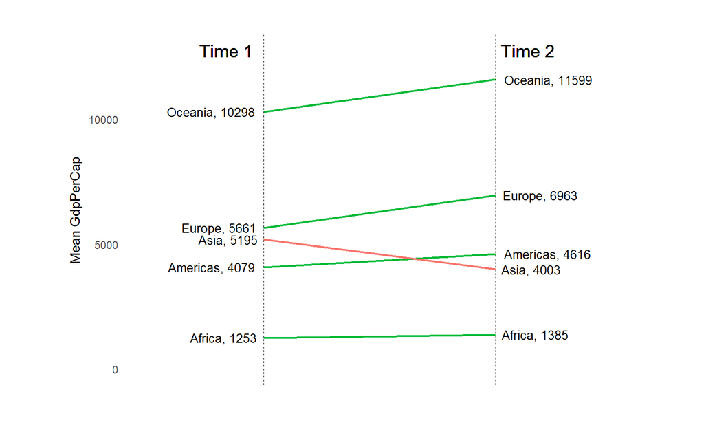

```r
# prep data
df <- read.csv("https://raw.githubusercontent.com/selva86/datasets/master/gdppercap.csv")
colnames(df) <- c("continent", "1952", "1957")
left_label <- paste(df$continent, round(df$`1952`),sep=", ")
right_label <- paste(df$continent, round(df$`1957`),sep=", ")
df$class <- ifelse((df$`1957` - df$`1952`) < 0, "red", "green")

ggplot(df) + geom_segment(aes(x=1, xend=2, y=`1952`, yend=`1957`, col=class), size=.75, show.legend=F) +
  geom_vline(xintercept=1, linetype="dashed", size=.1) +
  geom_vline(xintercept=2, linetype="dashed", size=.1) +
  scale_color_manual(labels = c("Up", "Down"),
                     values = c("green"="#00ba38", "red"="#f8766d")) +  # color of lines
  labs(x="", y="Mean GdpPerCap") +  # Axis labels
  xlim(.5, 2.5) + ylim(0,(1.1*(max(df$`1952`, df$`1957`)))) + # X and Y axis limits
  geom_text(label=left_label, y=df$`1952`, x=rep(1, NROW(df)), hjust=1.1, size=3.5) +
  geom_text(label=right_label, y=df$`1957`, x=rep(2, NROW(df)), hjust=-0.1, size=3.5) +
  geom_text(label="Time 1", x=1, y=1.1*(max(df$`1952`, df$`1957`)), hjust=1.2, size=5) +  # title
  geom_text(label="Time 2", x=2, y=1.1*(max(df$`1952`, df$`1957`)), hjust=-0.1, size=5) + # title
  theme(panel.background = element_blank(),panel.grid = element_blank(),axis.ticks = element_blank(),
          axis.text.x = element_blank(),panel.border = element_blank(),plot.margin = unit(c(1,2,1,2), "cm"))
```

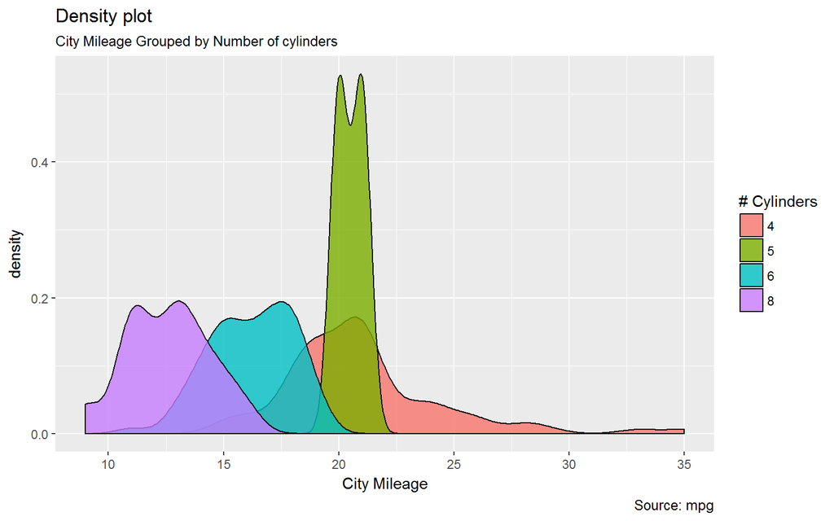

```r
ggplot(mpg, aes(cty)) +
  geom_density(aes(fill=factor(cyl)), alpha=0.8) +
  labs(title="Density plot",
       subtitle="City Mileage Grouped by Number of cylinders",
       caption="Source: mpg",
       x="City Mileage",
       fill="# Cylinders")
```

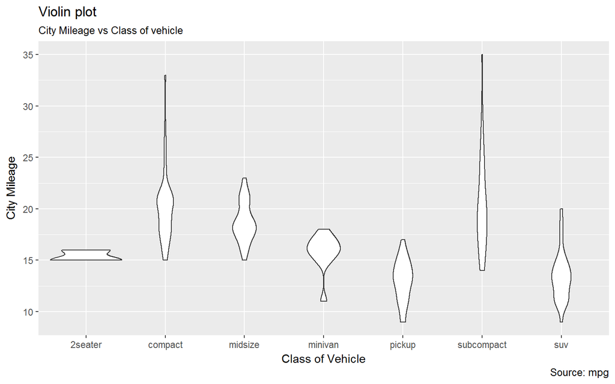

```r
ggplot(mpg, aes(class, cty)) +
  geom_violin() +
  labs(title="Violin plot",
       subtitle="City Mileage vs Class of vehicle",
       caption="Source: mpg",
       x="Class of Vehicle",
       y="City Mileage")
```

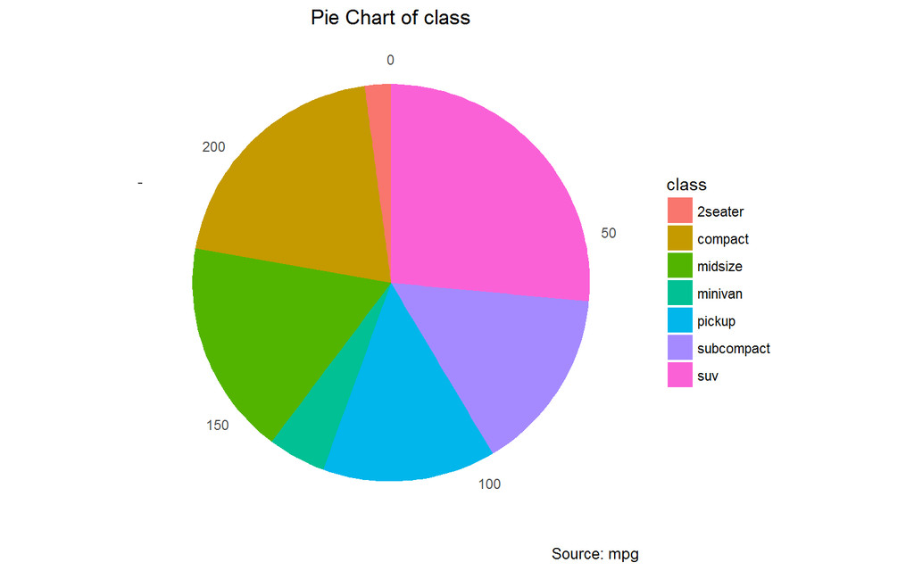

```r
theme_set(theme_classic())
df <- as.data.frame(table(mpg$class))
colnames(df) <- c("class", "freq")
ggplot(df, aes(x = "", y=freq, fill = factor(class))) +
  geom_bar(width = 1, stat = "identity") +
  theme(axis.line = element_blank(),
        plot.title = element_text(hjust=0.5)) +
  labs(fill="class",
       x=NULL,
       y=NULL,
       title="Pie Chart of class",
       caption="Source: mpg") +
  coord_polar(theta = "y", start=0)
```

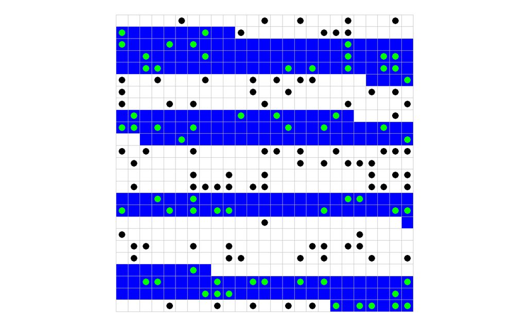

```r
EncSz  <-  25
SynPermCon  <-  0.5
PtPrcnt <- 0.75
SPSmpSz <- round(EncSz^2*PtPrcnt)
ENC <- rep(.3,EncSz^2)
ENC[c(19:83,200:250,353:420,497:585)] <- 1
SPEncBoxes <- tibble(x = rep(c(1:EncSz),EncSz), y = sort(rep(c(1:EncSz),EncSz)))
j <- rep(NA,EncSz^2)
j[sample(EncSz^2,SPSmpSz)] <- rnorm(SPSmpSz,mean=.9*SynPermCon,sd=SynPermCon/5)
j2 <- rep(NA,EncSz^2)
j2[j>0.5] <- 1
j2[j>0.5 & ENC ==1] <- 2
j2[is.na(j)] <- NA
EncAct <- rep(0.1,EncSz^2)
EncAct[j>SynPermCon] <- 1
j <- cut(j,breaks = c(-Inf,seq(0.4,0.6,0.025),Inf))
BlnkGrph = theme(axis.line=element_blank(), axis.text.x=element_blank(), axis.text.y=element_blank(), axis.ticks=element_blank(), axis.title.x=element_blank(),
                 axis.title.y=element_blank(), legend.position="none", panel.background=element_blank(), panel.border=element_blank(), panel.grid.major=element_blank(),
                 panel.grid.minor=element_blank(), plot.background=element_blank(),plot.margin=grid::unit(c(0,0,0,0), "mm"))
SPEncBoxes %>% ggplot(aes(x,y,fill = factor(round(ENC)))) +
  geom_tile(color = "gray",show.legend=FALSE) + BlnkGrph + coord_fixed() +
  geom_point(aes(x,y, color = factor(j2)),shape = 16,na.rm=TRUE, size = 3) +
  scale_fill_manual(values = c("white","blue")) + scale_shape_identity() +
  scale_color_manual(values = c("black","green"))
```

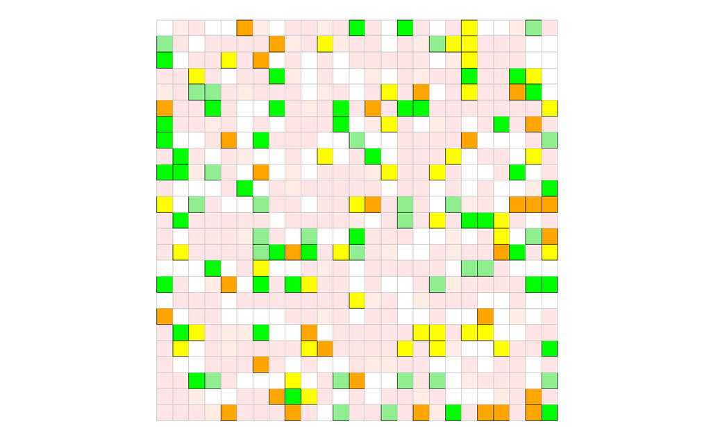

```r
SPEncBoxes %>% ggplot(aes(x,y,fill = j, color = EncAct)) +
  geom_tile(show.legend=FALSE, size = 0.2,alpha=EncAct) + BlnkGrph + coord_fixed() +
  scale_color_gradient(low="gray",high ="black") +
  scale_fill_manual(values = c("red","red","red","red","orangered", "orange","yellow","lightgreen","green1","green1"),na.value="white")
```

# Spend some time playing with ggplot

- See http://ggplot2.tidyverse.org/reference/ for a full list of functions in ggplot
- Here are a list of the datasets built into ggplot (use ?“dataset name” to find out more about the individual datasets)
  - diamonds
    - Prices of 50,000 round cut diamonds
  - economics
    - US economic time series
  - faithfuld
    - 2d density estimate of Old Faithful data
  - midwest
    - Midwest demographics
  - mpg
    - Fuel economy data from 1999 and 2008 for 38 popular models of car
  - msleep
    - An updated and expanded version of the mammals sleep dataset
  - presidential
    - Terms of 11 presidents from Eisenhower to Obama
  - seals
    - Vector field of seal movements
  - txhousing
    - Housing sales in TX
  - luv_colours
    - colors() in Luv space

# SECTION 3 - Data Manipulation

# Mathematical and Boolean Operators

```r
-sqrt(25) + (5 + 3)/4 * 7 - 2^2
```

```
## [1] 5
```

```r
5%/%3  # Integer Division
```

```
## [1] 1
```

```r
5%%3  # Modulo (remainder after division)
```

```
## [1] 2
```

```r
5 == 6
```

```
## [1] FALSE
```

```r
5 != 6
```

```
## [1] TRUE
```

```r
83 > (25 >= 23)
```

```
## [1] TRUE
```

```r
5 > 3 & 3 < 2
```

```
## [1] FALSE
```

```r
5 > 3 | 3 < 2
```

```
## [1] TRUE
```

# Vectors and Sequences

```r
1:4
```

```
## [1] 1 2 3 4
```

```r
c(5, 3, 2, 1)  # Creates a vector via concatenation (hence the c)
```

```
## [1] 5 3 2 1
```

```r
c(12, 1:4, 6)
```

```
## [1] 12  1  2  3  4  6
```

```r
seq(from = 1, t = 10, by = 2)  # Creates a vector with the given paramters
```

```
## [1] 1 3 5 7 9
```

```r
seq(1, 10, 2)  # creates the same vector without naming the paramters
```

```
## [1] 1 3 5 7 9
```

```r
seq(1, 10)  # R uses the default values for any empty parameters
```

```
##  [1]  1  2  3  4  5  6  7  8  9 10
```

```r
seq(to = 10, by = 2)
```

```
## [1] 1 3 5 7 9
```

```r
seq(by = 2, to = 10)
```

```
## [1] 1 3 5 7 9
```

```r
c(seq(1, 10, 2), 25, 10)
```

```
## [1]  1  3  5  7  9 25 10
```

```r
c(seq(1, 10, 2), 25, 10) > 12
```

```
## [1] FALSE FALSE FALSE FALSE FALSE  TRUE FALSE
```

```r
c(seq(1, 10, 2), 25, 10) * 2
```

```
## [1]  2  6 10 14 18 50 20
```

# Variables and Assignment

```r
x = 5 + 3
(x = 5 + 3)
```

```
## [1] 8
```

```r
x <- 5 + 3
(x <- 5 + 3)
```

```
## [1] 8
```

- Terminology
  - The term on the left hand side is referred to as an object
  - The term on the right hand side is the object’s value
  - The `<-` is the assignment operator

```r
y <- x
y
```

```
## [1] 8
```

```r
x <- 5 + 3 > 2
x
```

```
## [1] TRUE
```

```r
x <- seq(172, 23, -13)
x
```

```
##  [1] 172 159 146 133 120 107  94  81  68  55  42  29
```

# Indexing

- Indexing is locating values by their index/indices within an N dimensional object
- Unlike some other programming languages R starts at 1
- Note that indexing uses [], while functions, like `seq`, use ()

```r
x <- seq(172, 23, -13)
x[1]
```

```
## [1] 172
```

```r
x[c(1, 3)]
```

```
## [1] 172 146
```

```r
x[2:4]
```

```
## [1] 159 146 133
```

```r
x[4:2]
```

```
## [1] 133 146 159
```

```r
x[]
```

```
##  [1] 172 159 146 133 120 107  94  81  68  55  42  29
```

```r
x[-1]
```

```
##  [1] 159 146 133 120 107  94  81  68  55  42  29
```

```r
x[-c(1, 3)]
```

```
##  [1] 159 133 120 107  94  81  68  55  42  29
```

```r
x[x%%2 == 0]
```

```
## [1] 172 146 120  94  68  42
```

```r
y <- x[x%%2 == 0]
y[9] <- 10
y
```

```
## [1] 172 146 120  94  68  42  NA  NA  10
```

# Built in Functions

```r
x <- 1:20
mean(x)
```

```
## [1] 10.5
```

```r
max(x)
```

```
## [1] 20
```

```r
min(x)
```

```
## [1] 1
```

```r
length(x)
```

```
## [1] 20
```

```r
range(x)
```

```
## [1]  1 20
```

```r
prod(x)
```

```
## [1] 2.432902e+18
```

```r
var(x)
```

```
## [1] 35
```

```r
log(x)
```

```
##  [1] 0.0000000 0.6931472 1.0986123 1.3862944 1.6094379 1.7917595 1.9459101 2.0794415 2.1972246 2.3025851 2.3978953
## [12] 2.4849066 2.5649494 2.6390573 2.7080502 2.7725887 2.8332133 2.8903718 2.9444390 2.9957323
```

```r
sqrt(x)
```

```
##  [1] 1.000000 1.414214 1.732051 2.000000 2.236068 2.449490 2.645751 2.828427 3.000000 3.162278 3.316625 3.464102
## [13] 3.605551 3.741657 3.872983 4.000000 4.123106 4.242641 4.358899 4.472136
```

Note that many functions in R have default values for some of their parameters and you should always try to be aware of them even if you don’t want to change them

```r
rnorm(10)
```

```
##  [1] -0.35493248 -0.36965233  0.10493582 -0.45874993  0.41134117  0.14126034  0.00449645 -0.35426992  0.24333677
## [10]  0.46428302
```

`rnorm` randomly generates values from a normal distribution, but a normal distribution requires a mean and a standard deviation. If you type `?rnorm` you will see the full documentation but for our purposes the important part is

> rnorm(n, mean = 0, sd = 1)

By default, the `rnorm` function assumes a mean of 0 and a standard deviation of 1. You can change those values easily, but only if you are aware of them.

# Exercises

1. Create a vector of 2 through 8 squared:
   - 4, 9, 16, 25, 36, 49, 64
2. Create a vector of the square roots of the sum of sqaures of every pair of digits of 1 to 100:
   - sqrt(1^2 + 2^2), sqrt(3^2 + 4^2), sqrt(5^2 + 6^2), … , sqrt(99^2 + 100^2)
3. Create a vector of the numbers 1 to 100 not divisible by 3 or 5:
   - 1, 2, 4, 7, 8, 11, 13, 14, 16, 17, … , 97, 98

# Data frames

When you have data consisting of multiple observations of multiple variables, i.e., a data set, this is most conveniently stored as a dataframe

```r
iris  # Famous iris data set which gives the measurements for 50 flowers from each of 3 species of iris
```

```
##     Sepal.Length Sepal.Width Petal.Length Petal.Width    Species
## 1            5.1         3.5          1.4         0.2     setosa
## 2            4.9         3.0          1.4         0.2     setosa
## 3            4.7         3.2          1.3         0.2     setosa
## 4            4.6         3.1          1.5         0.2     setosa
## 5            5.0         3.6          1.4         0.2     setosa
## 6            5.4         3.9          1.7         0.4     setosa
## 7            4.6         3.4          1.4         0.3     setosa
## 8            5.0         3.4          1.5         0.2     setosa
## 9            4.4         2.9          1.4         0.2     setosa
## 10           4.9         3.1          1.5         0.1     setosa
## 11           5.4         3.7          1.5         0.2     setosa
## 12           4.8         3.4          1.6         0.2     setosa
## 13           4.8         3.0          1.4         0.1     setosa
## 14           4.3         3.0          1.1         0.1     setosa
```

[output cut: 136 more lines]

```r
summary(iris)  # Very useful function, which gives summaries of each variable
```

```
##   Sepal.Length    Sepal.Width     Petal.Length    Petal.Width          Species
##  Min.   :4.300   Min.   :2.000   Min.   :1.000   Min.   :0.100   setosa    :50
##  1st Qu.:5.100   1st Qu.:2.800   1st Qu.:1.600   1st Qu.:0.300   versicolor:50
##  Median :5.800   Median :3.000   Median :4.350   Median :1.300   virginica :50
##  Mean   :5.843   Mean   :3.057   Mean   :3.758   Mean   :1.199
##  3rd Qu.:6.400   3rd Qu.:3.300   3rd Qu.:5.100   3rd Qu.:1.800
##  Max.   :7.900   Max.   :4.400   Max.   :6.900   Max.   :2.500
```

# Matching

- You can call a single variable fo a dataframe using any of the following formats
  - `dataset$variablename`
  - `dataset['variablename']`
  - `dataset[variable column position]`

```r
names(iris)
```

```
## [1] "Sepal.Length" "Sepal.Width"  "Petal.Length" "Petal.Width"  "Species"
```

```r
iris$Sepal.Length
```

```
##   [1] 5.1 4.9 4.7 4.6 5.0 5.4 4.6 5.0 4.4 4.9 5.4 4.8 4.8 4.3 5.8 5.7 5.4 5.1 5.7 5.1 5.4 5.1 4.6 5.1 4.8 5.0 5.0 5.2
##  [29] 5.2 4.7 4.8 5.4 5.2 5.5 4.9 5.0 5.5 4.9 4.4 5.1 5.0 4.5 4.4 5.0 5.1 4.8 5.1 4.6 5.3 5.0 7.0 6.4 6.9 5.5 6.5 5.7
##  [57] 6.3 4.9 6.6 5.2 5.0 5.9 6.0 6.1 5.6 6.7 5.6 5.8 6.2 5.6 5.9 6.1 6.3 6.1 6.4 6.6 6.8 6.7 6.0 5.7 5.5 5.5 5.8 6.0
##  [85] 5.4 6.0 6.7 6.3 5.6 5.5 5.5 6.1 5.8 5.0 5.6 5.7 5.7 6.2 5.1 5.7 6.3 5.8 7.1 6.3 6.5 7.6 4.9 7.3 6.7 7.2 6.5 6.4
## [113] 6.8 5.7 5.8 6.4 6.5 7.7 7.7 6.0 6.9 5.6 7.7 6.3 6.7 7.2 6.2 6.1 6.4 7.2 7.4 7.9 6.4 6.3 6.1 7.7 6.3 6.4 6.0 6.9
## [141] 6.7 6.9 5.8 6.8 6.7 6.7 6.3 6.5 6.2 5.9
```

```r
iris["Sepal.Length"]
```

```
##     Sepal.Length
## 1            5.1
## 2            4.9
## 3            4.7
## 4            4.6
## 5            5.0
## 6            5.4
## 7            4.6
## 8            5.0
## 9            4.4
## 10           4.9
## 11           5.4
## 12           4.8
## 13           4.8
## 14           4.3
```

[output cut: 136 more lines]

```r
iris[1]
```

```
##     Sepal.Length
## 1            5.1
## 2            4.9
## 3            4.7
## 4            4.6
## 5            5.0
## 6            5.4
## 7            4.6
## 8            5.0
## 9            4.4
## 10           4.9
## 11           5.4
## 12           4.8
## 13           4.8
## 14           4.3
```

[output cut: 136 more lines]

# Indexing

- To call specific elements from the data set you can use either
  - Variable indexing using the `$` identifier, then using brackets after the variable name to indicate specific position(s)
  - Two element indexing, where the first element is the row and the second element is the column (name or position)

```r
iris$Sepal.Length[25:30]
```

```
## [1] 4.8 5.0 5.0 5.2 5.2 4.7
```

```r
iris[25:30, "Sepal.Length"]
```

```
## [1] 4.8 5.0 5.0 5.2 5.2 4.7
```

```r
iris[25:30, 1]
```

```
## [1] 4.8 5.0 5.0 5.2 5.2 4.7
```

```r
iris[c(25:30, 17, 1), c(1, 4)]
```

```
##    Sepal.Length Petal.Width
## 25          4.8         0.2
## 26          5.0         0.2
## 27          5.0         0.4
## 28          5.2         0.2
## 29          5.2         0.2
## 30          4.7         0.2
## 17          5.4         0.4
## 1           5.1         0.2
```

# Trouble with Tibbles

[figure not shown]

# Tibbles

- While the dataframes built into R are very useful, they are lacking in certain features
- Tibbles are a type of data frame that are lazy (they don’t change variable names or types) and surly (e.g., they complain when a variable does not exist)
- Tibbles differ from traditional data frames in two key ways, printing and subsetting

```r
iris
```

```
##     Sepal.Length Sepal.Width Petal.Length Petal.Width    Species
## 1            5.1         3.5          1.4         0.2     setosa
## 2            4.9         3.0          1.4         0.2     setosa
## 3            4.7         3.2          1.3         0.2     setosa
## 4            4.6         3.1          1.5         0.2     setosa
## 5            5.0         3.6          1.4         0.2     setosa
## 6            5.4         3.9          1.7         0.4     setosa
## 7            4.6         3.4          1.4         0.3     setosa
## 8            5.0         3.4          1.5         0.2     setosa
## 9            4.4         2.9          1.4         0.2     setosa
## 10           4.9         3.1          1.5         0.1     setosa
## 11           5.4         3.7          1.5         0.2     setosa
## 12           4.8         3.4          1.6         0.2     setosa
## 13           4.8         3.0          1.4         0.1     setosa
## 14           4.3         3.0          1.1         0.1     setosa
```

[output cut: 136 more lines]

```r
as_tibble(iris)  # shows only a few rows as well as the type of data in each row
```

```
## # A tibble: 150 × 5
##    Sepal.Length Sepal.Width Petal.Length Petal.Width Species
##           <dbl>       <dbl>        <dbl>       <dbl>  <fctr>
## 1           5.1         3.5          1.4         0.2  setosa
## 2           4.9         3.0          1.4         0.2  setosa
## 3           4.7         3.2          1.3         0.2  setosa
## 4           4.6         3.1          1.5         0.2  setosa
## 5           5.0         3.6          1.4         0.2  setosa
## 6           5.4         3.9          1.7         0.4  setosa
## 7           4.6         3.4          1.4         0.3  setosa
## 8           5.0         3.4          1.5         0.2  setosa
## 9           4.4         2.9          1.4         0.2  setosa
## 10          4.9         3.1          1.5         0.1  setosa
## # ... with 140 more rows
```

# Tibbles - Partial Matching

```r
iris$Spec
```

```
##   [1] setosa     setosa     setosa     setosa     setosa     setosa     setosa     setosa     setosa     setosa
##  [11] setosa     setosa     setosa     setosa     setosa     setosa     setosa     setosa     setosa     setosa
##  [21] setosa     setosa     setosa     setosa     setosa     setosa     setosa     setosa     setosa     setosa
##  [31] setosa     setosa     setosa     setosa     setosa     setosa     setosa     setosa     setosa     setosa
##  [41] setosa     setosa     setosa     setosa     setosa     setosa     setosa     setosa     setosa     setosa
##  [51] versicolor versicolor versicolor versicolor versicolor versicolor versicolor versicolor versicolor versicolor
##  [61] versicolor versicolor versicolor versicolor versicolor versicolor versicolor versicolor versicolor versicolor
##  [71] versicolor versicolor versicolor versicolor versicolor versicolor versicolor versicolor versicolor versicolor
##  [81] versicolor versicolor versicolor versicolor versicolor versicolor versicolor versicolor versicolor versicolor
##  [91] versicolor versicolor versicolor versicolor versicolor versicolor versicolor versicolor versicolor versicolor
## [101] virginica  virginica  virginica  virginica  virginica  virginica  virginica  virginica  virginica  virginica
## [111] virginica  virginica  virginica  virginica  virginica  virginica  virginica  virginica  virginica  virginica
## [121] virginica  virginica  virginica  virginica  virginica  virginica  virginica  virginica  virginica  virginica
## [131] virginica  virginica  virginica  virginica  virginica  virginica  virginica  virginica  virginica  virginica
## [141] virginica  virginica  virginica  virginica  virginica  virginica  virginica  virginica  virginica  virginica
## Levels: setosa versicolor virginica
```

```r
as_tibble(iris)$Spec
```

[output not shown]

# Tibbles - Subsetting

```r
iris[1]
```

```
##     Sepal.Length
## 1            5.1
## 2            4.9
## 3            4.7
## 4            4.6
## 5            5.0
## 6            5.4
## 7            4.6
## 8            5.0
## 9            4.4
## 10           4.9
## 11           5.4
## 12           4.8
## 13           4.8
## 14           4.3
```

[output cut: 136 more lines]

```r
iris[, 1]
```

```
##   [1] 5.1 4.9 4.7 4.6 5.0 5.4 4.6 5.0 4.4 4.9 5.4 4.8 4.8 4.3 5.8 5.7 5.4 5.1 5.7 5.1 5.4 5.1 4.6 5.1 4.8 5.0 5.0 5.2
##  [29] 5.2 4.7 4.8 5.4 5.2 5.5 4.9 5.0 5.5 4.9 4.4 5.1 5.0 4.5 4.4 5.0 5.1 4.8 5.1 4.6 5.3 5.0 7.0 6.4 6.9 5.5 6.5 5.7
##  [57] 6.3 4.9 6.6 5.2 5.0 5.9 6.0 6.1 5.6 6.7 5.6 5.8 6.2 5.6 5.9 6.1 6.3 6.1 6.4 6.6 6.8 6.7 6.0 5.7 5.5 5.5 5.8 6.0
##  [85] 5.4 6.0 6.7 6.3 5.6 5.5 5.5 6.1 5.8 5.0 5.6 5.7 5.7 6.2 5.1 5.7 6.3 5.8 7.1 6.3 6.5 7.6 4.9 7.3 6.7 7.2 6.5 6.4
## [113] 6.8 5.7 5.8 6.4 6.5 7.7 7.7 6.0 6.9 5.6 7.7 6.3 6.7 7.2 6.2 6.1 6.4 7.2 7.4 7.9 6.4 6.3 6.1 7.7 6.3 6.4 6.0 6.9
## [141] 6.7 6.9 5.8 6.8 6.7 6.7 6.3 6.5 6.2 5.9
```

```r
as_tibble(iris)[1]
```

```
## # A tibble: 150 × 1
##    Sepal.Length
##           <dbl>
## 1           5.1
## 2           4.9
## 3           4.7
## 4           4.6
## 5           5.0
## 6           5.4
## 7           4.6
## 8           5.0
## 9           4.4
## 10          4.9
## # ... with 140 more rows
```

```r
as_tibble(iris)[, 1]
```

```
## # A tibble: 150 × 1
##    Sepal.Length
##           <dbl>
## 1           5.1
## 2           4.9
## 3           4.7
## 4           4.6
## 5           5.0
## 6           5.4
## 7           4.6
## 8           5.0
## 9           4.4
## 10          4.9
## # ... with 140 more rows
```

```r
as_tibble(iris)[[1]]
```

```
##   [1] 5.1 4.9 4.7 4.6 5.0 5.4 4.6 5.0 4.4 4.9 5.4 4.8 4.8 4.3 5.8 5.7 5.4 5.1 5.7 5.1 5.4 5.1 4.6 5.1 4.8 5.0 5.0 5.2
##  [29] 5.2 4.7 4.8 5.4 5.2 5.5 4.9 5.0 5.5 4.9 4.4 5.1 5.0 4.5 4.4 5.0 5.1 4.8 5.1 4.6 5.3 5.0 7.0 6.4 6.9 5.5 6.5 5.7
##  [57] 6.3 4.9 6.6 5.2 5.0 5.9 6.0 6.1 5.6 6.7 5.6 5.8 6.2 5.6 5.9 6.1 6.3 6.1 6.4 6.6 6.8 6.7 6.0 5.7 5.5 5.5 5.8 6.0
##  [85] 5.4 6.0 6.7 6.3 5.6 5.5 5.5 6.1 5.8 5.0 5.6 5.7 5.7 6.2 5.1 5.7 6.3 5.8 7.1 6.3 6.5 7.6 4.9 7.3 6.7 7.2 6.5 6.4
## [113] 6.8 5.7 5.8 6.4 6.5 7.7 7.7 6.0 6.9 5.6 7.7 6.3 6.7 7.2 6.2 6.1 6.4 7.2 7.4 7.9 6.4 6.3 6.1 7.7 6.3 6.4 6.0 6.9
## [141] 6.7 6.9 5.8 6.8 6.7 6.7 6.3 6.5 6.2 5.9
```

# dplyr and the 5 + 1 verbs of data manipulation

dplyr is one of the packages in tidyverse which provides a consistent set of data manipulation verbs.

1. filter
   - Select based on values
2. arrange
   - reorder
3. select & rename
   - select based on names
4. mutate & transmute
   - add new variables that are functions of existing variables
5. summarise
   - condense multiple values to a single value
6. group by
   - perform any operation by group

# dplyr syntax

- The structure of the verbs is the same regardless of which one you use
  - verb(data frame, variable1/argument1, variable2/argument2, …)
  - The result is a new data frame

```r
filter(iris, Sepal.Length > 4, Petal.Width == 0.1)  # Note that the variable names do not have quotes, '', around them
```

```
##   Sepal.Length Sepal.Width Petal.Length Petal.Width Species
## 1          4.9         3.1          1.5         0.1  setosa
## 2          4.8         3.0          1.4         0.1  setosa
## 3          4.3         3.0          1.1         0.1  setosa
## 4          5.2         4.1          1.5         0.1  setosa
## 5          4.9         3.6          1.4         0.1  setosa
```

# Flights dataset

- On-time data for all flights that departed NYC (i.e. JFK, LGA or EWR) in 2013
- Install the nycflights13 package, `install.packages("nycflights13")`, and load its library, `library(nycflights13)`.

```r
library(nycflights13)
flights
```

```
## # A tibble: 336,776 × 19
##     year month   day dep_time sched_dep_time dep_delay arr_time sched_arr_time arr_delay carrier flight tailnum origin
##    <int> <int> <int>    <int>          <int>     <dbl>    <int>          <int>     <dbl>   <chr>  <int>   <chr>  <chr>
## 1   2013     1     1      517            515         2      830            819        11      UA   1545  N14228    EWR
## 2   2013     1     1      533            529         4      850            830        20      UA   1714  N24211    LGA
## 3   2013     1     1      542            540         2      923            850        33      AA   1141  N619AA    JFK
## 4   2013     1     1      544            545        -1     1004           1022       -18      B6    725  N804JB    JFK
## 5   2013     1     1      554            600        -6      812            837       -25      DL    461  N668DN    LGA
## 6   2013     1     1      554            558        -4      740            728        12      UA   1696  N39463    EWR
## 7   2013     1     1      555            600        -5      913            854        19      B6    507  N516JB    EWR
## 8   2013     1     1      557            600        -3      709            723       -14      EV   5708  N829AS    LGA
## 9   2013     1     1      557            600        -3      838            846        -8      B6     79  N593JB    JFK
## 10  2013     1     1      558            600        -2      753            745         8      AA    301  N3ALAA    LGA
## # ... with 336,766 more rows, and 6 more variables: dest <chr>, air_time <dbl>, distance <dbl>, hour <dbl>,
## #   minute <dbl>, time_hour <dttm>
```

```r
summary(flights)
```

```
##       year          month             day           dep_time    sched_dep_time   dep_delay          arr_time
##  Min.   :2013   Min.   : 1.000   Min.   : 1.00   Min.   :   1   Min.   : 106   Min.   : -43.00   Min.   :   1
##  1st Qu.:2013   1st Qu.: 4.000   1st Qu.: 8.00   1st Qu.: 907   1st Qu.: 906   1st Qu.:  -5.00   1st Qu.:1104
##  Median :2013   Median : 7.000   Median :16.00   Median :1401   Median :1359   Median :  -2.00   Median :1535
##  Mean   :2013   Mean   : 6.549   Mean   :15.71   Mean   :1349   Mean   :1344   Mean   :  12.64   Mean   :1502
##  3rd Qu.:2013   3rd Qu.:10.000   3rd Qu.:23.00   3rd Qu.:1744   3rd Qu.:1729   3rd Qu.:  11.00   3rd Qu.:1940
##  Max.   :2013   Max.   :12.000   Max.   :31.00   Max.   :2400   Max.   :2359   Max.   :1301.00   Max.   :2400
##                                                  NA's   :8255                  NA's   :8255      NA's   :8713
##  sched_arr_time   arr_delay          carrier              flight       tailnum             origin
##  Min.   :   1   Min.   : -86.000   Length:336776      Min.   :   1   Length:336776      Length:336776
##  1st Qu.:1124   1st Qu.: -17.000   Class :character   1st Qu.: 553   Class :character   Class :character
##  Median :1556   Median :  -5.000   Mode  :character   Median :1496   Mode  :character   Mode  :character
##  Mean   :1536   Mean   :   6.895                      Mean   :1972
##  3rd Qu.:1945   3rd Qu.:  14.000                      3rd Qu.:3465
##  Max.   :2359   Max.   :1272.000                      Max.   :8500
##                 NA's   :9430
##      dest              air_time        distance         hour           minute        time_hour
##  Length:336776      Min.   : 20.0   Min.   :  17   Min.   : 1.00   Min.   : 0.00   Min.   :2013-01-01 05:00:00
##  Class :character   1st Qu.: 82.0   1st Qu.: 502   1st Qu.: 9.00   1st Qu.: 8.00   1st Qu.:2013-04-04 13:00:00
##  Mode  :character   Median :129.0   Median : 872   Median :13.00   Median :29.00   Median :2013-07-03 10:00:00
##                     Mean   :150.7   Mean   :1040   Mean   :13.18   Mean   :26.23   Mean   :2013-07-03 05:02:36
##                     3rd Qu.:192.0   3rd Qu.:1389   3rd Qu.:17.00   3rd Qu.:44.00   3rd Qu.:2013-10-01 07:00:00
##                     Max.   :695.0   Max.   :4983   Max.   :23.00   Max.   :59.00   Max.   :2013-12-31 23:00:00
##                     NA's   :9430
```

# Data Types

- `int` integers
- `dbl` doubles or real numbers
- `chr` character vectors (strings)
- `dttm` date-time
- `date` date
- `lgl` logical (TRUE or FALSE)
- `fctr` factors (catgeorical variables with fixed possible values, e.g., dropdown list)
- `list` like a vector but can contain different types of elements

```r
flights[c("dep_time", "tailnum", "air_time", "time_hour")]
```

```
## # A tibble: 336,776 × 4
##    dep_time tailnum air_time           time_hour
##       <int>   <chr>    <dbl>              <dttm>
## 1       517  N14228      227 2013-01-01 05:00:00
## 2       533  N24211      227 2013-01-01 05:00:00
## 3       542  N619AA      160 2013-01-01 05:00:00
## 4       544  N804JB      183 2013-01-01 05:00:00
## 5       554  N668DN      116 2013-01-01 06:00:00
## 6       554  N39463      150 2013-01-01 05:00:00
## 7       555  N516JB      158 2013-01-01 06:00:00
## 8       557  N829AS       53 2013-01-01 06:00:00
## 9       557  N593JB      140 2013-01-01 06:00:00
## 10      558  N3ALAA      138 2013-01-01 06:00:00
## # ... with 336,766 more rows
```

# filter

use `filter()` to find rows/cases where conditions are true

```r
# Find all flights which went from JFK to Fort Lauderdale in the first week of January
filter(flights, origin == "JFK", dest == "FLL", month == 1, day <= 7)
```

```
## # A tibble: 106 × 19
##     year month   day dep_time sched_dep_time dep_delay arr_time sched_arr_time arr_delay carrier flight tailnum origin
##    <int> <int> <int>    <int>          <int>     <dbl>    <int>          <int>     <dbl>   <chr>  <int>   <chr>  <chr>
## 1   2013     1     1      659            700        -1     1008           1007         1      B6    981  N646JB    JFK
## 2   2013     1     1      712            715        -3     1023           1035       -12      AA    825  N3ETAA    JFK
## 3   2013     1     1      805            800         5     1118           1106        12      B6      3  N570JB    JFK
## 4   2013     1     1      933            904        29     1252           1210        42      B6     17  N579JB    JFK
## 5   2013     1     1     1153           1123        30     1454           1425        29      B6      1  N552JB    JFK
## 6   2013     1     1     1251           1252        -1     1611           1555        16      B6     85  N657JB    JFK
## 7   2013     1     1     1452           1457        -5     1753           1811       -18      B6     61  N292JB    JFK
## 8   2013     1     1     1527           1530        -3     1841           1855       -14      AA   1039  N3HYAA    JFK
## 9   2013     1     1     1610           1615        -5     1913           1948       -35      DL   1411  N947DL    JFK
## 10  2013     1     1     1713           1700        13     2006           2014        -8      B6     15  N346JB    JFK
## # ... with 96 more rows, and 6 more variables: dest <chr>, air_time <dbl>, distance <dbl>, hour <dbl>, minute <dbl>,
## #   time_hour <dttm>
```

```r
filter(flights, (origin == "JFK" | dest == "FLL"), month == 1, day <= 7)  # , is the same as AND and | is the same as OR
```

```
## # A tibble: 2,340 × 19
##     year month   day dep_time sched_dep_time dep_delay arr_time sched_arr_time arr_delay carrier flight tailnum origin
##    <int> <int> <int>    <int>          <int>     <dbl>    <int>          <int>     <dbl>   <chr>  <int>   <chr>  <chr>
## 1   2013     1     1      542            540         2      923            850        33      AA   1141  N619AA    JFK
## 2   2013     1     1      544            545        -1     1004           1022       -18      B6    725  N804JB    JFK
## 3   2013     1     1      555            600        -5      913            854        19      B6    507  N516JB    EWR
## 4   2013     1     1      557            600        -3      838            846        -8      B6     79  N593JB    JFK
## 5   2013     1     1      558            600        -2      849            851        -2      B6     49  N793JB    JFK
## 6   2013     1     1      558            600        -2      853            856        -3      B6     71  N657JB    JFK
## 7   2013     1     1      558            600        -2      924            917         7      UA    194  N29129    JFK
## 8   2013     1     1      559            559         0      702            706        -4      B6   1806  N708JB    JFK
## 9   2013     1     1      600            600         0      851            858        -7      B6    371  N595JB    LGA
## 10  2013     1     1      606            610        -4      837            845        -8      DL   1743  N3739P    JFK
## # ... with 2,330 more rows, and 6 more variables: dest <chr>, air_time <dbl>, distance <dbl>, hour <dbl>, minute <dbl>,
## #   time_hour <dttm>
```

```r
# Find all flights going to Fort Lauderdale, Atlanta or O'Hare
filter(flights, dest == "FLL" | dest == "ATL" | dest == "ORD")
```

```
## # A tibble: 46,553 × 19
##     year month   day dep_time sched_dep_time dep_delay arr_time sched_arr_time arr_delay carrier flight tailnum origin
##    <int> <int> <int>    <int>          <int>     <dbl>    <int>          <int>     <dbl>   <chr>  <int>   <chr>  <chr>
## 1   2013     1     1      554            600        -6      812            837       -25      DL    461  N668DN    LGA
## 2   2013     1     1      554            558        -4      740            728        12      UA   1696  N39463    EWR
## 3   2013     1     1      555            600        -5      913            854        19      B6    507  N516JB    EWR
## 4   2013     1     1      558            600        -2      753            745         8      AA    301  N3ALAA    LGA
## 5   2013     1     1      600            600         0      851            858        -7      B6    371  N595JB    LGA
## 6   2013     1     1      600            600         0      837            825        12      MQ   4650  N542MQ    LGA
## 7   2013     1     1      606            610        -4      837            845        -8      DL   1743  N3739P    JFK
## 8   2013     1     1      608            600         8      807            735        32      MQ   3768  N9EAMQ    EWR
## 9   2013     1     1      615            615         0      833            842        -9      DL    575  N326NB    EWR
## 10  2013     1     1      629            630        -1      824            810        14      AA    303  N3CYAA    LGA
## # ... with 46,543 more rows, and 6 more variables: dest <chr>, air_time <dbl>, distance <dbl>, hour <dbl>,
## #   minute <dbl>, time_hour <dttm>
```

```r
filter(flights, dest %in% c("FLL", "ATL", "ORD"))  # use %in% to search for multiple values in a single variable
```

```
## # A tibble: 46,553 × 19
##     year month   day dep_time sched_dep_time dep_delay arr_time sched_arr_time arr_delay carrier flight tailnum origin
##    <int> <int> <int>    <int>          <int>     <dbl>    <int>          <int>     <dbl>   <chr>  <int>   <chr>  <chr>
## 1   2013     1     1      554            600        -6      812            837       -25      DL    461  N668DN    LGA
## 2   2013     1     1      554            558        -4      740            728        12      UA   1696  N39463    EWR
## 3   2013     1     1      555            600        -5      913            854        19      B6    507  N516JB    EWR
## 4   2013     1     1      558            600        -2      753            745         8      AA    301  N3ALAA    LGA
## 5   2013     1     1      600            600         0      851            858        -7      B6    371  N595JB    LGA
## 6   2013     1     1      600            600         0      837            825        12      MQ   4650  N542MQ    LGA
## 7   2013     1     1      606            610        -4      837            845        -8      DL   1743  N3739P    JFK
## 8   2013     1     1      608            600         8      807            735        32      MQ   3768  N9EAMQ    EWR
## 9   2013     1     1      615            615         0      833            842        -9      DL    575  N326NB    EWR
## 10  2013     1     1      629            630        -1      824            810        14      AA    303  N3CYAA    LGA
## # ... with 46,543 more rows, and 6 more variables: dest <chr>, air_time <dbl>, distance <dbl>, hour <dbl>,
## #   minute <dbl>, time_hour <dttm>
```

```r
# Find all flights that have values for their departure delays
filter(flights, is.na(dep_delay))  # show all the rows with NA (missing values)
```

```
## # A tibble: 8,255 × 19
##     year month   day dep_time sched_dep_time dep_delay arr_time sched_arr_time arr_delay carrier flight tailnum origin
##    <int> <int> <int>    <int>          <int>     <dbl>    <int>          <int>     <dbl>   <chr>  <int>   <chr>  <chr>
## 1   2013     1     1       NA           1630        NA       NA           1815        NA      EV   4308  N18120    EWR
## 2   2013     1     1       NA           1935        NA       NA           2240        NA      AA    791  N3EHAA    LGA
## 3   2013     1     1       NA           1500        NA       NA           1825        NA      AA   1925  N3EVAA    LGA
## 4   2013     1     1       NA            600        NA       NA            901        NA      B6    125  N618JB    JFK
## 5   2013     1     2       NA           1540        NA       NA           1747        NA      EV   4352  N10575    EWR
## 6   2013     1     2       NA           1620        NA       NA           1746        NA      EV   4406  N13949    EWR
## 7   2013     1     2       NA           1355        NA       NA           1459        NA      EV   4434  N10575    EWR
## 8   2013     1     2       NA           1420        NA       NA           1644        NA      EV   4935  N759EV    EWR
## 9   2013     1     2       NA           1321        NA       NA           1536        NA      EV   3849  N13550    EWR
## 10  2013     1     2       NA           1545        NA       NA           1910        NA      AA    133    <NA>    JFK
## # ... with 8,245 more rows, and 6 more variables: dest <chr>, air_time <dbl>, distance <dbl>, hour <dbl>, minute <dbl>,
## #   time_hour <dttm>
```

```r
filter(flights, !is.na(dep_delay))  # show only the rows without missing values
```

```
## # A tibble: 328,521 × 19
##     year month   day dep_time sched_dep_time dep_delay arr_time sched_arr_time arr_delay carrier flight tailnum origin
##    <int> <int> <int>    <int>          <int>     <dbl>    <int>          <int>     <dbl>   <chr>  <int>   <chr>  <chr>
## 1   2013     1     1      517            515         2      830            819        11      UA   1545  N14228    EWR
## 2   2013     1     1      533            529         4      850            830        20      UA   1714  N24211    LGA
## 3   2013     1     1      542            540         2      923            850        33      AA   1141  N619AA    JFK
## 4   2013     1     1      544            545        -1     1004           1022       -18      B6    725  N804JB    JFK
## 5   2013     1     1      554            600        -6      812            837       -25      DL    461  N668DN    LGA
## 6   2013     1     1      554            558        -4      740            728        12      UA   1696  N39463    EWR
## 7   2013     1     1      555            600        -5      913            854        19      B6    507  N516JB    EWR
## 8   2013     1     1      557            600        -3      709            723       -14      EV   5708  N829AS    LGA
## 9   2013     1     1      557            600        -3      838            846        -8      B6     79  N593JB    JFK
## 10  2013     1     1      558            600        -2      753            745         8      AA    301  N3ALAA    LGA
## # ... with 328,511 more rows, and 6 more variables: dest <chr>, air_time <dbl>, distance <dbl>, hour <dbl>,
## #   minute <dbl>, time_hour <dttm>
```

# arrange

use `arrange()` to sort the data based on one or more variables

```r
# Sort the flights based on their scheduled departure time
arrange(flights, sched_dep_time)
```

```
## # A tibble: 336,776 × 19
##     year month   day dep_time sched_dep_time dep_delay arr_time sched_arr_time arr_delay carrier flight tailnum origin
##    <int> <int> <int>    <int>          <int>     <dbl>    <int>          <int>     <dbl>   <chr>  <int>   <chr>  <chr>
## 1   2013     7    27       NA            106        NA       NA            245        NA      US   1632    <NA>    EWR
## 2   2013     1     2      458            500        -2      703            650        13      US   1030  N162UW    EWR
## 3   2013     1     3      458            500        -2      650            650         0      US   1030  N172US    EWR
## 4   2013     1     4      456            500        -4      631            650       -19      US   1030  N186US    EWR
## 5   2013     1     5      458            500        -2      640            650       -10      US   1030  N560UW    EWR
## 6   2013     1     6      458            500        -2      718            650        28      US   1030  N539UW    EWR
## 7   2013     1     7      454            500        -6      637            648       -11      US   1117  N566UW    EWR
## 8   2013     1     8      454            500        -6      625            648       -23      US   1117  N564UW    EWR
## 9   2013     1     9      457            500        -3      647            648        -1      US   1117  N566UW    EWR
## 10  2013     1    10      450            500       -10      634            648       -14      US   1117  N171US    EWR
## # ... with 336,766 more rows, and 6 more variables: dest <chr>, air_time <dbl>, distance <dbl>, hour <dbl>,
## #   minute <dbl>, time_hour <dttm>
```

```r
# Sort the flights based on their scheduled departure time, and break ties using their actual departure time
arrange(flights, sched_dep_time, dep_time)
```

```
## # A tibble: 336,776 × 19
##     year month   day dep_time sched_dep_time dep_delay arr_time sched_arr_time arr_delay carrier flight tailnum origin
##    <int> <int> <int>    <int>          <int>     <dbl>    <int>          <int>     <dbl>   <chr>  <int>   <chr>  <chr>
## 1   2013     7    27       NA            106        NA       NA            245        NA      US   1632    <NA>    EWR
## 2   2013     5     8      445            500       -15      620            640       -20      US   1431  N537UW    EWR
## 3   2013     5     5      446            500       -14      636            640        -4      US   1579  N768US    EWR
## 4   2013     9     4      446            500       -14      618            648       -30      US   1877  N567UW    EWR
## 5   2013    10     1      447            500       -13      614            648       -34      US   1877  N538UW    EWR
## 6   2013     9    19      447            500       -13      620            648       -28      US   1877  N199UW    EWR
## 7   2013     1    29      448            500       -12      635            648       -13      US   1117  N172US    EWR
## 8   2013    12    27      448            500       -12      648            651        -3      US   1895  N543UW    EWR
## 9   2013     5     7      448            500       -12      624            640       -16      US   1099  N565UW    EWR
## 10  2013    10     2      449            500       -11      620            648       -28      US   1877  N193UW    EWR
## # ... with 336,766 more rows, and 6 more variables: dest <chr>, air_time <dbl>, distance <dbl>, hour <dbl>,
## #   minute <dbl>, time_hour <dttm>
```

```r
# Sort the flights by those scheduled to depart latest, and break ties in that group by those who left earliest
arrange(flights, desc(sched_dep_time), dep_time)
```

```
## # A tibble: 336,776 × 19
##     year month   day dep_time sched_dep_time dep_delay arr_time sched_arr_time arr_delay carrier flight tailnum origin
##    <int> <int> <int>    <int>          <int>     <dbl>    <int>          <int>     <dbl>   <chr>  <int>   <chr>  <chr>
## 1   2013    11    13        1           2359         2      442            440         2      B6   1503  N627JB    JFK
## 2   2013    12    16        1           2359         2      447            437        10      B6    839  N607JB    JFK
## 3   2013    12    20        1           2359         2      430            440       -10      B6   1503  N608JB    JFK
## 4   2013    12    26        1           2359         2      437            440        -3      B6   1503  N527JB    JFK
## 5   2013    12    30        1           2359         2      441            437         4      B6    839  N508JB    JFK
## 6   2013     4     5        1           2359         2      410            339        31      B6    727  N606JB    JFK
## 7   2013     5    25        1           2359         2      336            341        -5      B6    727  N523JB    JFK
## 8   2013     6    20        1           2359         2      340            350       -10      B6    745  N517JB    JFK
## 9   2013     7    27        1           2359         2      345            340         5      B6    839  N503JB    JFK
## 10  2013     7    28        1           2359         2      423            350        33      B6    745  N703JB    JFK
## # ... with 336,766 more rows, and 6 more variables: dest <chr>, air_time <dbl>, distance <dbl>, hour <dbl>,
## #   minute <dbl>, time_hour <dttm>
```

- The problems is I forgot about flights which were delayed so left the next morning
- Since dep_time is day agnostic, this does not give me the data I am looking for
- I can try and figure out which flights left that day and which left the next or just use a different variable as my metric of the late evening flights which left earliest.

```r
arrange(flights, desc(sched_dep_time), dep_delay)
```

```
## # A tibble: 336,776 × 19
##     year month   day dep_time sched_dep_time dep_delay arr_time sched_arr_time arr_delay carrier flight tailnum origin
##    <int> <int> <int>    <int>          <int>     <dbl>    <int>          <int>     <dbl>   <chr>  <int>   <chr>  <chr>
## 1   2013    10     2     2341           2359       -18      324            350       -26      B6    745  N527JB    JFK
## 2   2013     9    23     2342           2359       -17      331            350       -19      B6    745  N503JB    JFK
## 3   2013    10    22     2343           2359       -16      347            350        -3      B6    745  N592JB    JFK
## 4   2013     3     4     2343           2359       -16      418            438       -20      B6    727  N603JB    JFK
## 5   2013     1    20     2344           2359       -15      428            437        -9      B6    727  N603JB    JFK
## 6   2013     4    16     2344           2359       -15      313            343       -30      B6    707  N554JB    JFK
## 7   2013     1    27     2345           2359       -14      424            444       -20      B6    739  N630JB    JFK
## 8   2013     3     3     2345           2359       -14      441            438         3      B6    727  N508JB    JFK
## 9   2013     3     5     2345           2359       -14      439            438         1      B6    727  N705JB    JFK
## 10  2013    10     6     2346           2359       -13      333            350       -17      B6    745  N636JB    JFK
## # ... with 336,766 more rows, and 6 more variables: dest <chr>, air_time <dbl>, distance <dbl>, hour <dbl>,
## #   minute <dbl>, time_hour <dttm>
```

# select & rename

use `select()` and `rename()` to pick variables based on their names

```r
# Select the year, month, day, dep_times, and sched_dep_time columns
select(flights, year, month, day, dep_time, sched_dep_time)
```

```
## # A tibble: 336,776 × 5
##     year month   day dep_time sched_dep_time
##    <int> <int> <int>    <int>          <int>
## 1   2013     1     1      517            515
## 2   2013     1     1      533            529
## 3   2013     1     1      542            540
## 4   2013     1     1      544            545
## 5   2013     1     1      554            600
## 6   2013     1     1      554            558
## 7   2013     1     1      555            600
## 8   2013     1     1      557            600
## 9   2013     1     1      557            600
## 10  2013     1     1      558            600
## # ... with 336,766 more rows
```

```r
select(flights, year:sched_dep_time)
```

```
## # A tibble: 336,776 × 5
##     year month   day dep_time sched_dep_time
##    <int> <int> <int>    <int>          <int>
## 1   2013     1     1      517            515
## 2   2013     1     1      533            529
## 3   2013     1     1      542            540
## 4   2013     1     1      544            545
## 5   2013     1     1      554            600
## 6   2013     1     1      554            558
## 7   2013     1     1      555            600
## 8   2013     1     1      557            600
## 9   2013     1     1      557            600
## 10  2013     1     1      558            600
## # ... with 336,766 more rows
```

```r
select(flights, 1:5)
```

```
## # A tibble: 336,776 × 5
##     year month   day dep_time sched_dep_time
##    <int> <int> <int>    <int>          <int>
## 1   2013     1     1      517            515
## 2   2013     1     1      533            529
## 3   2013     1     1      542            540
## 4   2013     1     1      544            545
## 5   2013     1     1      554            600
## 6   2013     1     1      554            558
## 7   2013     1     1      555            600
## 8   2013     1     1      557            600
## 9   2013     1     1      557            600
## 10  2013     1     1      558            600
## # ... with 336,766 more rows
```

```r
select(flights, -(dep_delay:time_hour))  # more useful when removing only a few columns
```

```
## # A tibble: 336,776 × 5
##     year month   day dep_time sched_dep_time
##    <int> <int> <int>    <int>          <int>
## 1   2013     1     1      517            515
## 2   2013     1     1      533            529
## 3   2013     1     1      542            540
## 4   2013     1     1      544            545
## 5   2013     1     1      554            600
## 6   2013     1     1      554            558
## 7   2013     1     1      555            600
## 8   2013     1     1      557            600
## 9   2013     1     1      557            600
## 10  2013     1     1      558            600
## # ... with 336,766 more rows
```

`rename` lets you change the name of a variable while still keeping the full data set

```r
rename(flights, sun_cycles = year)
```

```
## # A tibble: 336,776 × 19
##    sun_cycles month   day dep_time sched_dep_time dep_delay arr_time sched_arr_time arr_delay carrier flight tailnum
##         <int> <int> <int>    <int>          <int>     <dbl>    <int>          <int>     <dbl>   <chr>  <int>   <chr>
## 1        2013     1     1      517            515         2      830            819        11      UA   1545  N14228
## 2        2013     1     1      533            529         4      850            830        20      UA   1714  N24211
## 3        2013     1     1      542            540         2      923            850        33      AA   1141  N619AA
## 4        2013     1     1      544            545        -1     1004           1022       -18      B6    725  N804JB
## 5        2013     1     1      554            600        -6      812            837       -25      DL    461  N668DN
## 6        2013     1     1      554            558        -4      740            728        12      UA   1696  N39463
## 7        2013     1     1      555            600        -5      913            854        19      B6    507  N516JB
## 8        2013     1     1      557            600        -3      709            723       -14      EV   5708  N829AS
## 9        2013     1     1      557            600        -3      838            846        -8      B6     79  N593JB
## 10       2013     1     1      558            600        -2      753            745         8      AA    301  N3ALAA
## # ... with 336,766 more rows, and 7 more variables: origin <chr>, dest <chr>, air_time <dbl>, distance <dbl>,
## #   hour <dbl>, minute <dbl>, time_hour <dttm>
```

```r
flights  # Note that we are not assigning any of these outputs, so if you call the original dataset, it hasn't changed
```

```
## # A tibble: 336,776 × 19
##     year month   day dep_time sched_dep_time dep_delay arr_time sched_arr_time arr_delay carrier flight tailnum origin
##    <int> <int> <int>    <int>          <int>     <dbl>    <int>          <int>     <dbl>   <chr>  <int>   <chr>  <chr>
## 1   2013     1     1      517            515         2      830            819        11      UA   1545  N14228    EWR
## 2   2013     1     1      533            529         4      850            830        20      UA   1714  N24211    LGA
## 3   2013     1     1      542            540         2      923            850        33      AA   1141  N619AA    JFK
## 4   2013     1     1      544            545        -1     1004           1022       -18      B6    725  N804JB    JFK
## 5   2013     1     1      554            600        -6      812            837       -25      DL    461  N668DN    LGA
## 6   2013     1     1      554            558        -4      740            728        12      UA   1696  N39463    EWR
## 7   2013     1     1      555            600        -5      913            854        19      B6    507  N516JB    EWR
## 8   2013     1     1      557            600        -3      709            723       -14      EV   5708  N829AS    LGA
## 9   2013     1     1      557            600        -3      838            846        -8      B6     79  N593JB    JFK
## 10  2013     1     1      558            600        -2      753            745         8      AA    301  N3ALAA    LGA
## # ... with 336,766 more rows, and 6 more variables: dest <chr>, air_time <dbl>, distance <dbl>, hour <dbl>,
## #   minute <dbl>, time_hour <dttm>
```

The `everything()` helper lets you use `select` to rearrange the order of the variables

```r
select(flights, distance, air_time, everything())
```

```
## # A tibble: 336,776 × 19
##    distance air_time  year month   day dep_time sched_dep_time dep_delay arr_time sched_arr_time arr_delay carrier
##       <dbl>    <dbl> <int> <int> <int>    <int>          <int>     <dbl>    <int>          <int>     <dbl>   <chr>
## 1      1400      227  2013     1     1      517            515         2      830            819        11      UA
## 2      1416      227  2013     1     1      533            529         4      850            830        20      UA
## 3      1089      160  2013     1     1      542            540         2      923            850        33      AA
## 4      1576      183  2013     1     1      544            545        -1     1004           1022       -18      B6
## 5       762      116  2013     1     1      554            600        -6      812            837       -25      DL
## 6       719      150  2013     1     1      554            558        -4      740            728        12      UA
## 7      1065      158  2013     1     1      555            600        -5      913            854        19      B6
## 8       229       53  2013     1     1      557            600        -3      709            723       -14      EV
## 9       944      140  2013     1     1      557            600        -3      838            846        -8      B6
## 10      733      138  2013     1     1      558            600        -2      753            745         8      AA
## # ... with 336,766 more rows, and 7 more variables: flight <int>, tailnum <chr>, origin <chr>, dest <chr>, hour <dbl>,
## #   minute <dbl>, time_hour <dttm>
```

# mutate & transmute

`mutate` adds new variables, while `transmute` drops existing variables

```r
# create a subset of the full dataset so that you can see new variables being added
flights_sml <- select(flights, dep_time, arr_time, air_time, distance)
flights_sml
```

```
## # A tibble: 336,776 × 4
##    dep_time arr_time air_time distance
##       <int>    <int>    <dbl>    <dbl>
## 1       517      830      227     1400
## 2       533      850      227     1416
## 3       542      923      160     1089
## 4       544     1004      183     1576
## 5       554      812      116      762
## 6       554      740      150      719
## 7       555      913      158     1065
## 8       557      709       53      229
## 9       557      838      140      944
## 10      558      753      138      733
## # ... with 336,766 more rows
```

```r
mutate(flights_sml, avg_speed = distance/air_time, dep_hr = dep_time%/%100, dep_min = dep_time%%100)
```

```
## # A tibble: 336,776 × 7
##    dep_time arr_time air_time distance avg_speed dep_hr dep_min
##       <int>    <int>    <dbl>    <dbl>     <dbl>  <dbl>   <dbl>
## 1       517      830      227     1400  6.167401      5      17
## 2       533      850      227     1416  6.237885      5      33
## 3       542      923      160     1089  6.806250      5      42
## 4       544     1004      183     1576  8.612022      5      44
## 5       554      812      116      762  6.568966      5      54
## 6       554      740      150      719  4.793333      5      54
## 7       555      913      158     1065  6.740506      5      55
## 8       557      709       53      229  4.320755      5      57
## 9       557      838      140      944  6.742857      5      57
## 10      558      753      138      733  5.311594      5      58
## # ... with 336,766 more rows
```

```r
transmute(flights_sml, avg_speed = distance/air_time, dep_hr = dep_time%/%100, dep_min = dep_time%%100)
```

```
## # A tibble: 336,776 × 3
##    avg_speed dep_hr dep_min
##        <dbl>  <dbl>   <dbl>
## 1   6.167401      5      17
## 2   6.237885      5      33
## 3   6.806250      5      42
## 4   8.612022      5      44
## 5   6.568966      5      54
## 6   4.793333      5      54
## 7   6.740506      5      55
## 8   4.320755      5      57
## 9   6.742857      5      57
## 10  5.311594      5      58
## # ... with 336,766 more rows
```

- There are lots of useful functions which can be applied within mutate/transmute, use `?mutate` for the full suggested list
  - `lead()` and `lag()` find the next and previous values in a vector, respectively.
  - `cumsum()`, `cummean()`, and others (see help doc) take running sums, means and other properties

```r
# How much time is there between each flight and the next?
mutate(flights_sml, dep_time_offset = lag(dep_time), dep_time_lag = dep_time - lag(dep_time))
```

```
## # A tibble: 336,776 × 6
##    dep_time arr_time air_time distance dep_time_offset dep_time_lag
##       <int>    <int>    <dbl>    <dbl>           <int>        <int>
## 1       517      830      227     1400              NA           NA
## 2       533      850      227     1416             517           16
## 3       542      923      160     1089             533            9
## 4       544     1004      183     1576             542            2
## 5       554      812      116      762             544           10
## 6       554      740      150      719             554            0
## 7       555      913      158     1065             554            1
## 8       557      709       53      229             555            2
## 9       557      838      140      944             557            0
## 10      558      753      138      733             557            1
## # ... with 336,766 more rows
```

```r
mutate(flights_sml, dep_time_offset = lead(dep_time), dep_time_lead = lead(dep_time) - dep_time)
```

```
## # A tibble: 336,776 × 6
##    dep_time arr_time air_time distance dep_time_offset dep_time_lead
##       <int>    <int>    <dbl>    <dbl>           <int>         <int>
## 1       517      830      227     1400             533            16
## 2       533      850      227     1416             542             9
## 3       542      923      160     1089             544             2
## 4       544     1004      183     1576             554            10
## 5       554      812      116      762             554             0
## 6       554      740      150      719             555             1
## 7       555      913      158     1065             557             2
## 8       557      709       53      229             557             0
## 9       557      838      140      944             558             1
## 10      558      753      138      733             558             0
## # ... with 336,766 more rows
```

```r
mutate(flights_sml, total_dist = cumsum(distance))
```

```
## # A tibble: 336,776 × 5
##    dep_time arr_time air_time distance total_dist
##       <int>    <int>    <dbl>    <dbl>      <dbl>
## 1       517      830      227     1400       1400
## 2       533      850      227     1416       2816
## 3       542      923      160     1089       3905
## 4       544     1004      183     1576       5481
## 5       554      812      116      762       6243
## 6       554      740      150      719       6962
## 7       555      913      158     1065       8027
## 8       557      709       53      229       8256
## 9       557      838      140      944       9200
## 10      558      753      138      733       9933
## # ... with 336,766 more rows
```

# Summarise & Group by

Summarise reduces multiple values to a single summary metric

```r
summarise(flights, delay = mean(dep_delay))
```

```
## # A tibble: 1 × 1
##   delay
##   <dbl>
## 1    NA
```

- Why does this give us `NA`?
- In R, missing values are represented by the symbol `NA` (not available)
  - This is not to be confused with `NaN` (not a number), which refers to impossible values, e.g., dividing by zero
- When you try to do any operation that includes `NA` values, the output will always be `NA`
  - Think of `NA`’s as being any possible value, as a result any summary metric will result in an unknown quantity as the uknown `NA` value could have significantly impacted the results
- To solve this problem most R functions have the option to ignore `NA` value
  - Usually it is of the form `na.rm=TRUE`

```r
summarise(flights, delay = mean(dep_delay, na.rm = TRUE))
```

```
## # A tibble: 1 × 1
##      delay
##      <dbl>
## 1 12.63907
```

- By itself `summarise` isn’t that useful as we rarely want to reduce all our data down to a single metric
- `summarise` is much more useful when combined with the other expressions
  - For example, determining the average departure delay of all flights in January

```r
jan_delay <- filter(flights, month == 1)
summarise(jan_delay, delay = mean(dep_delay, na.rm = TRUE))
```

```
## # A tibble: 1 × 1
##      delay
##      <dbl>
## 1 10.03667
```

- However, the real power of `summarise` is seen when coupled with `group_by`
- `group_by` takes an existing tibble and converts it into a grouped tibble where operations are performed “by group”
  - By itself `group_by` does not change how the data looks, instead it changes how it interacts with the other verbs, most notably `summarise`

```r
flights_month <- group_by(flights, month)
flights_month
```

```
## Source: local data frame [336,776 x 19]
## Groups: month [12]
##
##     year month   day dep_time sched_dep_time dep_delay arr_time sched_arr_time arr_delay carrier flight tailnum origin
##    <int> <int> <int>    <int>          <int>     <dbl>    <int>          <int>     <dbl>   <chr>  <int>   <chr>  <chr>
## 1   2013     1     1      517            515         2      830            819        11      UA   1545  N14228    EWR
## 2   2013     1     1      533            529         4      850            830        20      UA   1714  N24211    LGA
## 3   2013     1     1      542            540         2      923            850        33      AA   1141  N619AA    JFK
## 4   2013     1     1      544            545        -1     1004           1022       -18      B6    725  N804JB    JFK
## 5   2013     1     1      554            600        -6      812            837       -25      DL    461  N668DN    LGA
## 6   2013     1     1      554            558        -4      740            728        12      UA   1696  N39463    EWR
## 7   2013     1     1      555            600        -5      913            854        19      B6    507  N516JB    EWR
## 8   2013     1     1      557            600        -3      709            723       -14      EV   5708  N829AS    LGA
## 9   2013     1     1      557            600        -3      838            846        -8      B6     79  N593JB    JFK
## 10  2013     1     1      558            600        -2      753            745         8      AA    301  N3ALAA    LGA
## # ... with 336,766 more rows, and 6 more variables: dest <chr>, air_time <dbl>, distance <dbl>, hour <dbl>,
## #   minute <dbl>, time_hour <dttm>
```

```r
summarise(flights_month, delay = mean(dep_delay, na.rm = TRUE))
```

```
## # A tibble: 12 × 2
##    month     delay
##    <int>     <dbl>
## 1      1 10.036665
## 2      2 10.816843
## 3      3 13.227076
## 4      4 13.938038
## 5      5 12.986859
## 6      6 20.846332
## 7      7 21.727787
## 8      8 12.611040
## 9      9  6.722476
## 10    10  6.243988
## 11    11  5.435362
## 12    12 16.576688
```

Also it’s good practice when grouping to add a counts column using `n()`

```r
summarise(flights_month, delay = mean(dep_delay, na.rm = TRUE), count = n())
```

```
## # A tibble: 12 × 3
##    month     delay count
##    <int>     <dbl> <int>
## 1      1 10.036665 27004
## 2      2 10.816843 24951
## 3      3 13.227076 28834
## 4      4 13.938038 28330
## 5      5 12.986859 28796
## 6      6 20.846332 28243
## 7      7 21.727787 29425
## 8      8 12.611040 29327
## 9      9  6.722476 27574
## 10    10  6.243988 28889
## 11    11  5.435362 27268
## 12    12 16.576688 28135
```

# Pipes


# Pipes

Often you will need to string multiple actions together which can get somewhat messy

```r
# On average which hour of the day has the most delayed american airline flights
flights_mut <- mutate(flights, hr = sched_dep_time%/%100)
flights_filt <- filter(flights_mut, carrier == "AA", complete.cases(flights_mut))
flights_sel <- select(flights_filt, dep_time, hr, sched_dep_time, dep_delay)
flights_sel  # print out to confirm that you are selecting what you intend
```

```
## # A tibble: 31,947 × 4
##    dep_time    hr sched_dep_time dep_delay
##       <int> <dbl>          <int>     <dbl>
## 1       542     5            540         2
## 2       558     6            600        -2
## 3       559     6            600        -1
## 4       606     6            610        -4
## 5       623     6            610        13
## 6       628     6            630        -2
## 7       629     6            630        -1
## 8       635     6            635         0
## 9       656     7            700        -4
## 10      656     6            659        -3
## # ... with 31,937 more rows
```

```r
flights_gb <- group_by(flights_sel, hr)
flights_sum <- summarise(flights_gb, mean_delay = mean(dep_delay), count = n())
flights_arr <- arrange(flights_sum, desc(mean_delay))
print(flights_arr, n = 24)
```

```
## # A tibble: 17 × 3
##       hr mean_delay count
##    <dbl>      <dbl> <int>
## 1     19 21.2870418  1937
## 2     17 19.9348861  3993
## 3     21 18.2857143   406
## 4     18 14.3431713  1728
## 5     15 12.3666921  2618
## 6     20 12.2851240   484
## 7     16 11.9728287  2061
## 8     14  7.7936709  1580
## 9     13  7.3642305  1683
## 10    10  5.8927536  1380
## 11    11  5.1475167  1349
## 12    12  4.9592920  2260
## 13     9  2.6576763  2410
## 14     8  2.1545312  1909
## 15     5  0.6814404   361
## 16     7 -0.4511713  3287
## 17     6 -1.0215914  2501
```

The pipes `%>%` or `CTRL`+`Shift`+`M` (from the magrittr package which is included in tidyverse) allows you to do the same set of actions in a much simpler manner

```r
flights %>%
  mutate(hr = sched_dep_time%/% 100) %>%
  filter(carrier == 'AA', complete.cases(flights_mut)) %>%
  select(dep_time, hr, sched_dep_time, dep_delay) %>%
  group_by(hr) %>%
  summarise(mean_delay = mean(dep_delay),count = n()) %>%
  arrange(desc(mean_delay))
```

```
## # A tibble: 17 × 3
##       hr mean_delay count
##    <dbl>      <dbl> <int>
## 1     19 21.2870418  1937
## 2     17 19.9348861  3993
## 3     21 18.2857143   406
## 4     18 14.3431713  1728
## 5     15 12.3666921  2618
## 6     20 12.2851240   484
## 7     16 11.9728287  2061
## 8     14  7.7936709  1580
## 9     13  7.3642305  1683
## 10    10  5.8927536  1380
## 11    11  5.1475167  1349
## 12    12  4.9592920  2260
## 13     9  2.6576763  2410
## 14     8  2.1545312  1909
## 15     5  0.6814404   361
## 16     7 -0.4511713  3287
## 17     6 -1.0215914  2501
```

- Pipes can be thought of as the phrase “and then”, so the above code would be read as:
  1. Take the input flights and then
  2. mutate it and then
  3. filter it and then
  4. select it and then …
- Pipes are useful when
  - There is only a single input and you don’t need to combine inputs
  - You only want a single ouptut and don’t care about the outputs from the intermediate steps
- But remember that without an assignment, the output is not saved to a variable

# Exercises & playtime

- Using the babynames dataset from the babynames package:
  1. How popular was your name in the US in the year you were born, i.e. how many other babies were given the same name?
  2. Which are the overall most popular girl and boy baby names as measured by count? How many times more popular are they then the next most popular names?
  3. Since 1990 how many girls have been named “Michael”
  4. What was the 8th most popular year for the name “Michael” as measured by counts?
  5. Which girl’s name had the biggest increase in consecutive years, in what years was it, and why?

The `fivethirtyeight` package has lots of fun datasets. To see the motivation behind the package’s creation as well as a description of each of the different datasets use `vignette("fivethirtyeight", package = "fivethirtyeight")`

# Combining Data Manipulation and Visualization

1. Plot the popularity of the boy’s name Brittany since 1950.
2. Using the 5 most popular girl’s name from 2015 (based on counts), plot their counts over all the years recorded, using different color for each name. Now plot the same names using the prop value instead.
3. Plot the number of names which have a significant share of the total names, i.e., > 1%, over all years recorded

# sECTION 3 - Data Importing/Cleaning

# Found vs Generated Data

- Most of the time in your research you will be using data that you or someone you know generated
  - This will often result in tidy and clean data or if not at least someone you can complain to about why the data is so messy
- But what about when you have to use 3rd party data, e.g., weather information
  - First you have to find the data (a topic we will not be covering)
  - Then you have to import the data
  - Then you have to clean and tidy the data
- Dataset formats
  - Columns are variables separated by a delimeter, such as a comma (.csv), semicolon (.csv2), tab (.tsv)
  - Rows are entries and their values form the index column of the data
    - Usually the values in the first row are the names of the columns

```r
# Trip Duration,Start Time,Stop Time,Start Station ID,Start Station Name

# 1893,2017-03-01 00:00:32,2017-03-01 00:32:06,2009,Catherine St & Monroe St

# 223,2017-03-01 00:01:09,2017-03-01 00:04:53,127,Barrow St & Hudson St

# 1665,2017-03-01 00:01:27,2017-03-01 00:29:12,174,E 25 St & 1 Ave

# 100,2017-03-01 00:01:29,2017-03-01 00:03:10,316,Fulton St & William St

# 1229,2017-03-01 00:01:33,2017-03-01 00:22:02,536,1 Ave & E 30 St

# 613,2017-03-01 00:01:57,2017-03-01 00:12:11,259,South St & Whitehall St

# 157,2017-03-01 00:02:12,2017-03-01 00:04:49,3329,Degraw St & Smith St
```

# Citibike Dataset

- Download the citibike_data directory from the same site where you folder where you downloaded the R file
  - The RBootcamp folder in https://github.com/mseinstein/Presentations
- This dataset is publicly available online from citibike and contains every ride for an entire month
- R has a built in function for reading csv files `read.csv()` which reads the data into a dataframe, but instead we will be using the tidyverse package readr, which uses the slightly different `read_csv()`
  - Feel free to compare the documentation for the two functions if you want to know how they differ
  - Since the `read_csv` function is powerful and versatile it’s good to look at its default options before using it

```r
# read_csv(file, col_names = TRUE, col_types = NULL,
#   locale = default_locale(), na = c("", "NA"), quoted_na = TRUE,
#   quote = "\"", comment = "", trim_ws = TRUE, skip = 0, n_max = Inf,
#   guess_max = min(1000, n_max), progress = show_progress())
```

- For the file variable use the full path (‘E:\full\path\to\file.csv’)
- Note that you can easily change the working directory but that is outside the scope of this bootcamp

```r
read_csv("E:/GitHub/Presentations/RBootcamp/citibike_data/201701-citibike-tripdata.csv")
```

```
## # A tibble: 726,676 × 15
##    `Trip Duration`        `Start Time`         `Stop Time` `Start Station ID`        `Start Station Name`
##              <int>              <dttm>              <dttm>              <int>                       <chr>
## 1              680 2017-01-01 00:00:21 2017-01-01 00:11:41               3226 W 82 St & Central Park West
## 2             1282 2017-01-01 00:00:45 2017-01-01 00:22:08               3263      Cooper Square & E 7 St
## 3              648 2017-01-01 00:00:57 2017-01-01 00:11:46               3143             5 Ave & E 78 St
## 4              631 2017-01-01 00:01:10 2017-01-01 00:11:42               3143             5 Ave & E 78 St
## 5              621 2017-01-01 00:01:25 2017-01-01 00:11:47               3143             5 Ave & E 78 St
## 6              666 2017-01-01 00:01:51 2017-01-01 00:12:57               3163 Central Park West & W 68 St
## 7              559 2017-01-01 00:05:00 2017-01-01 00:14:20                499          Broadway & W 60 St
## 8              826 2017-01-01 00:05:37 2017-01-01 00:19:24                362          Broadway & W 37 St
## 9              255 2017-01-01 00:05:47 2017-01-01 00:10:02                430            York St & Jay St
## 10             634 2017-01-01 00:07:34 2017-01-01 00:18:08               3165 Central Park West & W 72 St
## # ... with 726,666 more rows, and 10 more variables: `Start Station Latitude` <dbl>, `Start Station Longitude` <dbl>,
## #   `End Station ID` <int>, `End Station Name` <chr>, `End Station Latitude` <dbl>, `End Station Longitude` <dbl>,
## #   `Bike ID` <int>, `User Type` <chr>, `Birth Year` <int>, Gender <int>
```

You can see that R solved the problem of spaces in the column names by putting ` around them (note this is a backtick not a single quote), but this makes it annoying to refer to these variables. Instead we can use a snake case version of the column names as an input into `read_csv`

```r
column_names <- c("trip_duration", "start_time", "stop_time", "start_id", "start_name", "start_lat", "start_long", "end_id",
    "end_name", "end_lat", "end_long", "bike_id", "user_type", "birth_year", "gender")
read_csv("E:/GitHub/Presentations/RBootcamp/citibike_data/201701-citibike-tripdata.csv", col_names = column_names)
```

```
## # A tibble: 726,677 × 15
##    trip_duration          start_time           stop_time         start_id                  start_name
##            <chr>               <chr>               <chr>            <chr>                       <chr>
## 1  Trip Duration          Start Time           Stop Time Start Station ID          Start Station Name
## 2            680 2017-01-01 00:00:21 2017-01-01 00:11:41             3226 W 82 St & Central Park West
## 3           1282 2017-01-01 00:00:45 2017-01-01 00:22:08             3263      Cooper Square & E 7 St
## 4            648 2017-01-01 00:00:57 2017-01-01 00:11:46             3143             5 Ave & E 78 St
## 5            631 2017-01-01 00:01:10 2017-01-01 00:11:42             3143             5 Ave & E 78 St
## 6            621 2017-01-01 00:01:25 2017-01-01 00:11:47             3143             5 Ave & E 78 St
## 7            666 2017-01-01 00:01:51 2017-01-01 00:12:57             3163 Central Park West & W 68 St
## 8            559 2017-01-01 00:05:00 2017-01-01 00:14:20              499          Broadway & W 60 St
## 9            826 2017-01-01 00:05:37 2017-01-01 00:19:24              362          Broadway & W 37 St
## 10           255 2017-01-01 00:05:47 2017-01-01 00:10:02              430            York St & Jay St
## # ... with 726,667 more rows, and 10 more variables: start_lat <chr>, start_long <chr>, end_id <chr>, end_name <chr>,
## #   end_lat <chr>, end_long <chr>, bike_id <chr>, user_type <chr>, birth_year <chr>, gender <chr>
```

The problem is that when you provide the column names, `read_csv` treats the first row as a regular row of entries, so if we want to use our own column names we need to skip that row

```r
citi_bike <- read_csv("E:/GitHub/Presentations/RBootcamp/citibike_data/201701-citibike-tripdata.csv", col_names = column_names,
    skip = 1)
citi_bike
```

```
## # A tibble: 726,676 × 15
##    trip_duration          start_time           stop_time start_id                  start_name start_lat start_long
##            <int>              <dttm>              <dttm>    <int>                       <chr>     <dbl>      <dbl>
## 1            680 2017-01-01 00:00:21 2017-01-01 00:11:41     3226 W 82 St & Central Park West  40.78275  -73.97137
## 2           1282 2017-01-01 00:00:45 2017-01-01 00:22:08     3263      Cooper Square & E 7 St  40.72924  -73.99087
## 3            648 2017-01-01 00:00:57 2017-01-01 00:11:46     3143             5 Ave & E 78 St  40.77683  -73.96389
## 4            631 2017-01-01 00:01:10 2017-01-01 00:11:42     3143             5 Ave & E 78 St  40.77683  -73.96389
## 5            621 2017-01-01 00:01:25 2017-01-01 00:11:47     3143             5 Ave & E 78 St  40.77683  -73.96389
## 6            666 2017-01-01 00:01:51 2017-01-01 00:12:57     3163 Central Park West & W 68 St  40.77341  -73.97783
## 7            559 2017-01-01 00:05:00 2017-01-01 00:14:20      499          Broadway & W 60 St  40.76916  -73.98192
## 8            826 2017-01-01 00:05:37 2017-01-01 00:19:24      362          Broadway & W 37 St  40.75173  -73.98754
## 9            255 2017-01-01 00:05:47 2017-01-01 00:10:02      430            York St & Jay St  40.70149  -73.98657
## 10           634 2017-01-01 00:07:34 2017-01-01 00:18:08     3165 Central Park West & W 72 St  40.77579  -73.97621
## # ... with 726,666 more rows, and 8 more variables: end_id <int>, end_name <chr>, end_lat <dbl>, end_long <dbl>,
## #   bike_id <int>, user_type <chr>, birth_year <int>, gender <int>
```

# Parsing

- Parsing , in reference to `read_csv` and similar functions, is the method of analyzing elements of a vector to determine the type of information within that vector
- By default, `read_csv` uses the first 1000 rows or the entire dataset, whichever is smaller, to parse each column
- Usually it does a very good job and most of the time you have to change data types because you want a specific data type, not because of an error within the parser

```r
# Let's look again at our dataset and see if all our datatypes make sense
citi_bike
```

```
## # A tibble: 726,676 × 15
##    trip_duration          start_time           stop_time start_id                  start_name start_lat start_long end_id                    end_name  end_lat  end_long bike_id  user_type birth_year gender
##            <int>              <dttm>              <dttm>    <int>                       <chr>     <dbl>      <dbl>  <int>                       <chr>    <dbl>     <dbl>   <int>      <chr>      <int>  <int>
## 1            680 2017-01-01 00:00:21 2017-01-01 00:11:41     3226 W 82 St & Central Park West  40.78275  -73.97137   3165 Central Park West & W 72 St 40.77579 -73.97621   25542 Subscriber       1965      2
## 2           1282 2017-01-01 00:00:45 2017-01-01 00:22:08     3263      Cooper Square & E 7 St  40.72924  -73.99087    498          Broadway & W 32 St 40.74855 -73.98808   21136 Subscriber       1987      2
## 3            648 2017-01-01 00:00:57 2017-01-01 00:11:46     3143             5 Ave & E 78 St  40.77683  -73.96389   3152             3 Ave & E 71 St 40.76874 -73.96120   18147   Customer         NA      0
## 4            631 2017-01-01 00:01:10 2017-01-01 00:11:42     3143             5 Ave & E 78 St  40.77683  -73.96389   3152             3 Ave & E 71 St 40.76874 -73.96120   21211   Customer         NA      0
## 5            621 2017-01-01 00:01:25 2017-01-01 00:11:47     3143             5 Ave & E 78 St  40.77683  -73.96389   3152             3 Ave & E 71 St 40.76874 -73.96120   26819   Customer         NA      0
## 6            666 2017-01-01 00:01:51 2017-01-01 00:12:57     3163 Central Park West & W 68 St  40.77341  -73.97783   3163 Central Park West & W 68 St 40.77341 -73.97783   16050 Subscriber       2000      1
## 7            559 2017-01-01 00:05:00 2017-01-01 00:14:20      499          Broadway & W 60 St  40.76916  -73.98192    479             9 Ave & W 45 St 40.76019 -73.99126   27294 Subscriber       1973      1
## 8            826 2017-01-01 00:05:37 2017-01-01 00:19:24      362          Broadway & W 37 St  40.75173  -73.98754    445          E 10 St & Avenue A 40.72741 -73.98142   23288 Subscriber       1977      2
## 9            255 2017-01-01 00:05:47 2017-01-01 00:10:02      430            York St & Jay St  40.70149  -73.98657    242  Carlton Ave & Flushing Ave 40.69779 -73.97374   25041 Subscriber       1989      1
## 10           634 2017-01-01 00:07:34 2017-01-01 00:18:08     3165 Central Park West & W 72 St  40.77579  -73.97621   3164      Columbus Ave & W 72 St 40.77706 -73.97898   16311 Subscriber       1980      1
## # ... with 726,666 more rows
```

```r
summary(citi_bike)
```

```
##  trip_duration       start_time                    stop_time                      start_id     start_name
##  Min.   :     61   Min.   :2017-01-01 00:00:21   Min.   :2017-01-01 00:10:02   Min.   :  72   Length:726676
##  1st Qu.:    331   1st Qu.:2017-01-11 08:40:46   1st Qu.:2017-01-11 08:52:47   1st Qu.: 358   Class :character
##  Median :    526   Median :2017-01-18 09:25:48   Median :2017-01-18 09:37:23   Median : 482   Mode  :character
##  Mean   :    778   Mean   :2017-01-17 16:36:15   Mean   :2017-01-17 16:49:13   Mean   :1223
##  3rd Qu.:    860   3rd Qu.:2017-01-25 15:39:17   3rd Qu.:2017-01-25 15:52:34   3rd Qu.:3092
##  Max.   :5325688   Max.   :2017-01-31 23:59:23   Max.   :2017-03-14 14:13:45   Max.   :3446
##
##    start_lat       start_long         end_id       end_name            end_lat         end_long         bike_id
##  Min.   : 0.00   Min.   :-74.03   Min.   :  72   Length:726676      Min.   : 0.00   Min.   :-74.03   Min.   :14529
##  1st Qu.:40.72   1st Qu.:-74.00   1st Qu.: 356   Class :character   1st Qu.:40.72   1st Qu.:-74.00   1st Qu.:17859
##  Median :40.74   Median :-73.99   Median : 479   Mode  :character   Median :40.74   Median :-73.99   Median :21295
##  Mean   :40.74   Mean   :-73.98   Mean   :1197                      Mean   :40.74   Mean   :-73.99   Mean   :21713
##  3rd Qu.:40.76   3rd Qu.:-73.98   3rd Qu.:3078                      3rd Qu.:40.76   3rd Qu.:-73.98   3rd Qu.:25803
##  Max.   :40.80   Max.   :  0.00   Max.   :3447                      Max.   :40.80   Max.   :  0.00   Max.   :27325
##
##   user_type           birth_year        gender
##  Length:726676      Min.   :1885    Min.   :0.000
##  Class :character   1st Qu.:1969    1st Qu.:1.000
##  Mode  :character   Median :1979    Median :1.000
##                     Mean   :1977    Mean   :1.167
##                     3rd Qu.:1987    3rd Qu.:1.000
##                     Max.   :2000    Max.   :2.000
##                     NA's   :29076
```

- Double and integers are very useful for continuous values, but when you have a limited number of discrete values (and where the orders of the valuesare typically irrelevant), the factor type is often more useful
  - Factors are useful when you have a categorical variable (think of it like a dropdown menu)
  - Factor values are always converted to characters
  - The `level()` function list all the possible options of the factor variable
- There are two ways to convert a csv tibble column into a factor
  - When you initially read the file you can specify the type for each column (useful when changing most of the columns) using the `col_factor()` function
  - After reading the file you can convert the specified columns to factors using the `as.factor()` function

```r
# In the citi_bike case start_id, end_id, user_type and gender are all variables which should be factors
citi_bike_fac <- citi_bike %>% mutate(start_id = as.factor(start_id), end_id = as.factor(end_id), user_type = as.factor(user_type),
    gender = as.factor(gender))
citi_bike_fac
```

```
## # A tibble: 726,676 × 15
##    trip_duration          start_time           stop_time start_id                  start_name start_lat start_long
##            <int>              <dttm>              <dttm>   <fctr>                       <chr>     <dbl>      <dbl>
## 1            680 2017-01-01 00:00:21 2017-01-01 00:11:41     3226 W 82 St & Central Park West  40.78275  -73.97137
## 2           1282 2017-01-01 00:00:45 2017-01-01 00:22:08     3263      Cooper Square & E 7 St  40.72924  -73.99087
## 3            648 2017-01-01 00:00:57 2017-01-01 00:11:46     3143             5 Ave & E 78 St  40.77683  -73.96389
## 4            631 2017-01-01 00:01:10 2017-01-01 00:11:42     3143             5 Ave & E 78 St  40.77683  -73.96389
## 5            621 2017-01-01 00:01:25 2017-01-01 00:11:47     3143             5 Ave & E 78 St  40.77683  -73.96389
## 6            666 2017-01-01 00:01:51 2017-01-01 00:12:57     3163 Central Park West & W 68 St  40.77341  -73.97783
## 7            559 2017-01-01 00:05:00 2017-01-01 00:14:20      499          Broadway & W 60 St  40.76916  -73.98192
## 8            826 2017-01-01 00:05:37 2017-01-01 00:19:24      362          Broadway & W 37 St  40.75173  -73.98754
## 9            255 2017-01-01 00:05:47 2017-01-01 00:10:02      430            York St & Jay St  40.70149  -73.98657
## 10           634 2017-01-01 00:07:34 2017-01-01 00:18:08     3165 Central Park West & W 72 St  40.77579  -73.97621
## # ... with 726,666 more rows, and 8 more variables: end_id <fctr>, end_name <chr>, end_lat <dbl>, end_long <dbl>,
## #   bike_id <int>, user_type <fctr>, birth_year <int>, gender <fctr>
```

```r
levels(citi_bike_fac$gender)
```

```
## [1] "0" "1" "2"
```